# Covail

### Difference in risk between prototype and Omicon vaccines

#### Pfizer

OC v P is significant among the naive but not among the non-naive.

```r
coxph(update(f, ~. + naive + Trt), dat.ocp.pfizer)
```

```
## Call:
## coxph(formula = update(f, ~. + naive + Trt), data = dat.ocp.pfizer)
##
##                            coef exp(coef) se(coef)      z       p
## FOIstandardized         -0.1126    0.8935   0.2984 -0.377 0.70591
## standardized_risk_score  0.2795    1.3224   0.2878  0.971 0.33154
## naive                    0.8310    2.2955   0.4551  1.826 0.06787
## Trt                     -1.1399    0.3199   0.3749 -3.040 0.00236
##
## Likelihood ratio test=12.14  on 4 df, p=0.01631
## n= 151, number of events= 30
```

```r
coxph(update(f, ~. + Trt), subset(dat.ocp.pfizer, naive==0))
```

```
## Call:
## coxph(formula = update(f, ~. + Trt), data = subset(dat.ocp.pfizer,
##     naive == 0))
##
##                             coef exp(coef) se(coef)      z     p
## FOIstandardized          0.59531   1.81359  0.61480  0.968 0.333
## standardized_risk_score  0.04664   1.04775  0.52826  0.088 0.930
## Trt                     -0.52997   0.58862  0.77255 -0.686 0.493
##
## Likelihood ratio test=1.38  on 3 df, p=0.7098
## n= 53, number of events= 7
```

```r
coxph(update(f, ~. + Trt), subset(dat.ocp.pfizer, naive==1))
```

```
## Call:
## coxph(formula = update(f, ~. + Trt), data = subset(dat.ocp.pfizer,
##     naive == 1))
##
##                            coef exp(coef) se(coef)      z      p
## FOIstandardized         -0.3243    0.7231   0.3318 -0.977 0.3285
## standardized_risk_score  0.4130    1.5113   0.3592  1.150 0.2503
## Trt                     -1.3346    0.2633   0.4359 -3.062 0.0022
##
## Likelihood ratio test=10.59  on 3 df, p=0.01415
## n= 98, number of events= 23
```

```r
dat.1=subset(dat.ocp.pfizer, naive==1)
```

```r
coxph(update(f, ~. + naive + Trt), dat.ocp.moderna)
```

```
## Call:
## coxph(formula = update(f, ~. + naive + Trt), data = dat.ocp.moderna)
##
##                            coef exp(coef) se(coef)      z       p
## FOIstandardized         -0.1298    0.8782   0.1923 -0.675 0.49956
## standardized_risk_score  0.2056    1.2283   0.1441  1.427 0.15360
## naive                    1.0871    2.9657   0.3741  2.906 0.00367
## Trt                     -0.1180    0.8887   0.2388 -0.494 0.62124
##
## Likelihood ratio test=13.62  on 4 df, p=0.008612
## n= 284, number of events= 78
```

```r
coxph(update(f, ~. + Trt), subset(dat.ocp.moderna, naive==0))
```

```
## Call:
## coxph(formula = update(f, ~. + Trt), data = subset(dat.ocp.moderna,
##     naive == 0))
##
##                            coef exp(coef) se(coef)      z      p
## FOIstandardized         -0.4871    0.6144   0.5445 -0.895 0.3710
## standardized_risk_score -0.4855    0.6154   0.2100 -2.312 0.0208
## Trt                     -0.5147    0.5977   0.7306 -0.705 0.4811
##
## Likelihood ratio test=6.87  on 3 df, p=0.07628
## n= 64, number of events= 8
```

```r
coxph(update(f, ~. + Trt), subset(dat.ocp.moderna, naive==1))
```

```
## Call:
## coxph(formula = update(f, ~. + Trt), data = subset(dat.ocp.moderna,
##     naive == 1))
##
##                             coef exp(coef) se(coef)      z      p
## FOIstandardized         -0.03082   0.96965  0.20833 -0.148 0.8824
## standardized_risk_score  0.45535   1.57672  0.16296  2.794 0.0052
## Trt                     -0.07904   0.92400  0.25598 -0.309 0.7575
##
## Likelihood ratio test=8.48  on 3 df, p=0.03705
## n= 220, number of events= 70
```

```r
coxph(update(f, ~. + Trt), subset(dat.ocp.moderna, naive==1))
```

```
## Call:
## coxph(formula = update(f, ~. + Trt), data = subset(dat.ocp.moderna,
##     naive == 1))
##
##                             coef exp(coef) se(coef)      z      p
## FOIstandardized         -0.03082   0.96965  0.20833 -0.148 0.8824
## standardized_risk_score  0.45535   1.57672  0.16296  2.794 0.0052
## Trt                     -0.07904   0.92400  0.25598 -0.309 0.7575
##
## Likelihood ratio test=8.48  on 3 df, p=0.03705
## n= 220, number of events= 70
```

```r
coxph(update(f, ~. + Trt), subset(dat.ocp.pfizer, naive==1))
```

```
## Call:
## coxph(formula = update(f, ~. + Trt), data = subset(dat.ocp.pfizer,
##     naive == 1))
##
##                            coef exp(coef) se(coef)      z      p
## FOIstandardized         -0.3243    0.7231   0.3318 -0.977 0.3285
## standardized_risk_score  0.4130    1.5113   0.3592  1.150 0.2503
## Trt                     -1.3346    0.2633   0.4359 -3.062 0.0022
##
## Likelihood ratio test=10.59  on 3 df, p=0.01415
## n= 98, number of events= 23
```

```r
coxph(Surv(COVIDtimeD22toD181, COVIDIndD22toD181) ~ I(1-Trt)*scale(standardized_risk_score), subset(dat.ocp.moderna, naive==1))
```

```
## Call:
## coxph(formula = Surv(COVIDtimeD22toD181, COVIDIndD22toD181) ~
##     I(1 - Trt) * scale(standardized_risk_score), data = subset(dat.ocp.moderna,
##     naive == 1))
##
##                                              coef exp(coef) se(coef)      z
## I(1 - Trt)                                 0.1259    1.1341   0.2626  0.479
## scale(standardized_risk_score)             0.4569    1.5792   0.1567  2.917
## I(1 - Trt):scale(standardized_risk_score) -0.3079    0.7350   0.2860 -1.077
##                                                 p
## I(1 - Trt)                                0.63173
## scale(standardized_risk_score)            0.00354
## I(1 - Trt):scale(standardized_risk_score) 0.28163
##
## Likelihood ratio test=9.58  on 3 df, p=0.02251
## n= 220, number of events= 70
```

```r
coxph(Surv(COVIDtimeD22toD181, COVIDIndD22toD181) ~ I(1-Trt)*scale(standardized_risk_score), subset(dat.ocp.pfizer, naive==1))
```

```
## Call:
## coxph(formula = Surv(COVIDtimeD22toD181, COVIDIndD22toD181) ~
##     I(1 - Trt) * scale(standardized_risk_score), data = subset(dat.ocp.pfizer,
##     naive == 1))
##
##                                                coef exp(coef)  se(coef)      z
## I(1 - Trt)                                 1.334775  3.799141  0.439440  3.037
## scale(standardized_risk_score)             0.252246  1.286913  0.302894  0.833
## I(1 - Trt):scale(standardized_risk_score) -0.003043  0.996962  0.513319 -0.006
##                                                 p
## I(1 - Trt)                                0.00239
## scale(standardized_risk_score)            0.40496
## I(1 - Trt):scale(standardized_risk_score) 0.99527
##
## Likelihood ratio test=9.64  on 3 df, p=0.02186
## n= 98, number of events= 23
```

D15 marker

```r
coxph(Surv(COVIDtimeD22toD181, COVIDIndD22toD181) ~ I(1-Trt)*scale(standardized_risk_score) + I(1-Trt)*scale(Day15pseudoneutid50_BA.4.BA.5), subset(dat.ocp.moderna, naive==1))
```

```
## Call:
## coxph(formula = Surv(COVIDtimeD22toD181, COVIDIndD22toD181) ~
##     I(1 - Trt) * scale(standardized_risk_score) + I(1 - Trt) *
##         scale(Day15pseudoneutid50_BA.4.BA.5), data = subset(dat.ocp.moderna,
##     naive == 1))
##
##                                                    coef exp(coef) se(coef)
## I(1 - Trt)                                       0.1114    1.1178   0.2661
## scale(standardized_risk_score)                   0.4149    1.5142   0.1504
## scale(Day15pseudoneutid50_BA.4.BA.5)            -0.4160    0.6597   0.1256
## I(1 - Trt):scale(standardized_risk_score)       -0.2653    0.7670   0.2835
## I(1 - Trt):scale(Day15pseudoneutid50_BA.4.BA.5)  0.4191    1.5206   0.2328
##                                                      z        p
## I(1 - Trt)                                       0.419 0.675561
## scale(standardized_risk_score)                   2.759 0.005804
## scale(Day15pseudoneutid50_BA.4.BA.5)            -3.311 0.000929
## I(1 - Trt):scale(standardized_risk_score)       -0.936 0.349342
## I(1 - Trt):scale(Day15pseudoneutid50_BA.4.BA.5)  1.801 0.071746
##
## Likelihood ratio test=19.05  on 5 df, p=0.001884
## n= 220, number of events= 70
```

```r
coxph(Surv(COVIDtimeD22toD181, COVIDIndD22toD181) ~ I(1-Trt)*scale(standardized_risk_score) + I(1-Trt)*scale(Day15pseudoneutid50_BA.4.BA.5), subset(dat.ocp.pfizer, naive==1))
```

```
## Call:
## coxph(formula = Surv(COVIDtimeD22toD181, COVIDIndD22toD181) ~
##     I(1 - Trt) * scale(standardized_risk_score) + I(1 - Trt) *
##         scale(Day15pseudoneutid50_BA.4.BA.5), data = subset(dat.ocp.pfizer,
##     naive == 1))
##
##                                                     coef exp(coef) se(coef)
## I(1 - Trt)                                       1.22319   3.39801  0.47177
## scale(standardized_risk_score)                   0.25727   1.29339  0.28060
## scale(Day15pseudoneutid50_BA.4.BA.5)            -0.39649   0.67268  0.30594
## I(1 - Trt):scale(standardized_risk_score)       -0.07131   0.93117  0.51280
## I(1 - Trt):scale(Day15pseudoneutid50_BA.4.BA.5)  0.08472   1.08841  0.48874
##                                                      z       p
## I(1 - Trt)                                       2.593 0.00952
## scale(standardized_risk_score)                   0.917 0.35923
## scale(Day15pseudoneutid50_BA.4.BA.5)            -1.296 0.19498
## I(1 - Trt):scale(standardized_risk_score)       -0.139 0.88940
## I(1 - Trt):scale(Day15pseudoneutid50_BA.4.BA.5)  0.173 0.86239
##
## Likelihood ratio test=11.86  on 5 df, p=0.03673
## n= 98, number of events= 23
```

```r
coxph(Surv(COVIDtimeD22toD181, COVIDIndD22toD181) ~ Trt*scale(standardized_risk_score) + Trt*scale(Day15pseudoneutid50_BA.4.BA.5), subset(dat.ocp.moderna, naive==1))
```

```
## Call:
## coxph(formula = Surv(COVIDtimeD22toD181, COVIDIndD22toD181) ~
##     Trt * scale(standardized_risk_score) + Trt * scale(Day15pseudoneutid50_BA.4.BA.5),
##     data = subset(dat.ocp.moderna, naive == 1))
##
##                                               coef exp(coef)  se(coef)      z
## Trt                                      -0.111365  0.894612  0.266089 -0.419
## scale(standardized_risk_score)            0.149640  1.161417  0.240360  0.623
## scale(Day15pseudoneutid50_BA.4.BA.5)      0.003167  1.003172  0.195995  0.016
## Trt:scale(standardized_risk_score)        0.265277  1.303791  0.283455  0.936
## Trt:scale(Day15pseudoneutid50_BA.4.BA.5) -0.419130  0.657619  0.232756 -1.801
##                                               p
## Trt                                      0.6756
## scale(standardized_risk_score)           0.5336
## scale(Day15pseudoneutid50_BA.4.BA.5)     0.9871
## Trt:scale(standardized_risk_score)       0.3493
## Trt:scale(Day15pseudoneutid50_BA.4.BA.5) 0.0717
##
## Likelihood ratio test=19.05  on 5 df, p=0.001884
## n= 220, number of events= 70
```

```r
coxph(Surv(COVIDtimeD22toD181, COVIDIndD22toD181) ~ Trt*scale(standardized_risk_score) + Trt*scale(Day15pseudoneutid50_BA.4.BA.5), subset(dat.ocp.pfizer, naive==1))
```

```
## Call:
## coxph(formula = Surv(COVIDtimeD22toD181, COVIDIndD22toD181) ~
##     Trt * scale(standardized_risk_score) + Trt * scale(Day15pseudoneutid50_BA.4.BA.5),
##     data = subset(dat.ocp.pfizer, naive == 1))
##
##                                              coef exp(coef) se(coef)      z
## Trt                                      -1.22319   0.29429  0.47177 -2.593
## scale(standardized_risk_score)            0.18595   1.20437  0.42922  0.433
## scale(Day15pseudoneutid50_BA.4.BA.5)     -0.31177   0.73215  0.38065 -0.819
## Trt:scale(standardized_risk_score)        0.07131   1.07392  0.51280  0.139
## Trt:scale(Day15pseudoneutid50_BA.4.BA.5) -0.08472   0.91877  0.48874 -0.173
##                                                p
## Trt                                      0.00952
## scale(standardized_risk_score)           0.66484
## scale(Day15pseudoneutid50_BA.4.BA.5)     0.41276
## Trt:scale(standardized_risk_score)       0.88940
## Trt:scale(Day15pseudoneutid50_BA.4.BA.5) 0.86239
##
## Likelihood ratio test=11.86  on 5 df, p=0.03673
## n= 98, number of events= 23
```

```r
coxph(Surv(COVIDtimeD22toD181, COVIDIndD22toD181) ~ Trt*scale(standardized_risk_score) + scale(Day15pseudoneutid50_BA.4.BA.5), subset(dat.ocp.moderna, naive==1))
```

```
## Call:
## coxph(formula = Surv(COVIDtimeD22toD181, COVIDIndD22toD181) ~
##     Trt * scale(standardized_risk_score) + scale(Day15pseudoneutid50_BA.4.BA.5),
##     data = subset(dat.ocp.moderna, naive == 1))
##
##                                          coef exp(coef) se(coef)      z       p
## Trt                                   0.01104   1.01111  0.26824  0.041 0.96716
## scale(standardized_risk_score)        0.19188   1.21152  0.23255  0.825 0.40932
## scale(Day15pseudoneutid50_BA.4.BA.5) -0.27822   0.75713  0.10780 -2.581 0.00986
## Trt:scale(standardized_risk_score)    0.23881   1.26974  0.27919  0.855 0.39234
##
## Likelihood ratio test=15.7  on 4 df, p=0.003451
## n= 220, number of events= 70
```

```r
coxph(Surv(COVIDtimeD22toD181, COVIDIndD22toD181) ~ Trt+scale(standardized_risk_score) + scale(Day15pseudoneutid50_BA.4.BA.5), subset(dat.ocp.pfizer, naive==1))
```

```
## Call:
## coxph(formula = Surv(COVIDtimeD22toD181, COVIDIndD22toD181) ~
##     Trt + scale(standardized_risk_score) + scale(Day15pseudoneutid50_BA.4.BA.5),
##     data = subset(dat.ocp.pfizer, naive == 1))
##
##                                         coef exp(coef) se(coef)      z       p
## Trt                                  -1.1912    0.3039   0.4390 -2.713 0.00666
## scale(standardized_risk_score)        0.2285    1.2567   0.2312  0.988 0.32313
## scale(Day15pseudoneutid50_BA.4.BA.5) -0.3558    0.7006   0.2317 -1.536 0.12463
##
## Likelihood ratio test=11.81  on 3 df, p=0.008078
## n= 98, number of events= 23
```

BA4BA5-specific ID50 is significant correlate but not ancestral ID50.

```r
coxph(update(f, ~. + Trt * Bpseudoneutid50_BA.4.BA.5), dat.1)
```

```
## Call:
## coxph(formula = update(f, ~. + Trt * Bpseudoneutid50_BA.4.BA.5),
##     data = dat.1)
##
##                                   coef exp(coef) se(coef)      z     p
## FOIstandardized               -0.37008   0.69068  0.32778 -1.129 0.259
## standardized_risk_score        0.46192   1.58712  0.35856  1.288 0.198
## Trt                           -1.45196   0.23411  1.39782 -1.039 0.299
## Bpseudoneutid50_BA.4.BA.5     -0.76476   0.46545  0.51612 -1.482 0.138
## Trt:Bpseudoneutid50_BA.4.BA.5  0.02565   1.02598  0.75166  0.034 0.973
##
## Likelihood ratio test=14.86  on 5 df, p=0.011
## n= 98, number of events= 23
```

```r
coxph(update(f, ~. + Trt + Bpseudoneutid50_BA.4.BA.5), dat.1)
```

```
## Call:
## coxph(formula = update(f, ~. + Trt + Bpseudoneutid50_BA.4.BA.5),
##     data = dat.1)
##
##                              coef exp(coef) se(coef)      z       p
## FOIstandardized           -0.3707    0.6903   0.3275 -1.132 0.25778
## standardized_risk_score    0.4619    1.5871   0.3584  1.289 0.19754
## Trt                       -1.4067    0.2449   0.4402 -3.196 0.00139
## Bpseudoneutid50_BA.4.BA.5 -0.7528    0.4711   0.3771 -1.996 0.04593
##
## Likelihood ratio test=14.85  on 4 df, p=0.005012
## n= 98, number of events= 23
```

```r
coxph(update(f, ~. + Trt * Day15pseudoneutid50_BA.4.BA.5), dat.1)
```

```
## Call:
## coxph(formula = update(f, ~. + Trt * Day15pseudoneutid50_BA.4.BA.5),
##     data = dat.1)
##
##                                      coef exp(coef) se(coef)      z     p
## FOIstandardized                   -0.3928    0.6751   0.3376 -1.163 0.245
## standardized_risk_score            0.4077    1.5033   0.3387  1.204 0.229
## Trt                               -0.5003    0.6063   2.3862 -0.210 0.834
## Day15pseudoneutid50_BA.4.BA.5     -0.5345    0.5860   0.6290 -0.850 0.395
## Trt:Day15pseudoneutid50_BA.4.BA.5 -0.2392    0.7873   0.8374 -0.286 0.775
##
## Likelihood ratio test=13.19  on 5 df, p=0.0217
## n= 98, number of events= 23
```

```r
coxph(update(f, ~. + Trt + Day15pseudoneutid50_BA.4.BA.5), dat.1)
```

```
## Call:
## coxph(formula = update(f, ~. + Trt + Day15pseudoneutid50_BA.4.BA.5),
##     data = dat.1)
##
##                                  coef exp(coef) se(coef)      z       p
## FOIstandardized               -0.3846    0.6807   0.3365 -1.143 0.25298
## standardized_risk_score        0.3880    1.4741   0.3346  1.160 0.24613
## Trt                           -1.1710    0.3101   0.4380 -2.673 0.00751
## Day15pseudoneutid50_BA.4.BA.5 -0.6690    0.5122   0.4026 -1.661 0.09662
##
## Likelihood ratio test=13.1  on 4 df, p=0.01078
## n= 98, number of events= 23
```

```r
coxph(update(f, ~. + Trt * Bpseudoneutid50_D614G), dat.1)
```

```
## Call:
## coxph(formula = update(f, ~. + Trt * Bpseudoneutid50_D614G),
##     data = dat.1)
##
##                              coef exp(coef) se(coef)      z     p
## FOIstandardized           -0.3129    0.7313   0.3325 -0.941 0.347
## standardized_risk_score    0.3846    1.4690   0.3593  1.070 0.284
## Trt                       -2.5917    0.0749   3.0261 -0.856 0.392
## Bpseudoneutid50_D614G     -0.7526    0.4711   0.6990 -1.077 0.282
## Trt:Bpseudoneutid50_D614G  0.3747    1.4545   0.9066  0.413 0.679
##
## Likelihood ratio test=12.25  on 5 df, p=0.03156
## n= 98, number of events= 23
```

```r
coxph(update(f, ~. + Trt + Bpseudoneutid50_D614G), dat.1)
```

```
## Call:
## coxph(formula = update(f, ~. + Trt + Bpseudoneutid50_D614G),
##     data = dat.1)
##
##                            coef exp(coef) se(coef)      z       p
## FOIstandardized         -0.3433    0.7094   0.3265 -1.051 0.29307
## standardized_risk_score  0.4042    1.4981   0.3542  1.141 0.25378
## Trt                     -1.3536    0.2583   0.4357 -3.106 0.00189
## Bpseudoneutid50_D614G   -0.5220    0.5934   0.4159 -1.255 0.20949
##
## Likelihood ratio test=12.07  on 4 df, p=0.01682
## n= 98, number of events= 23
```

```r
coxph(update(f, ~. + Trt * Day15pseudoneutid50_D614G), dat.1)
```

```
## Call:
## coxph(formula = update(f, ~. + Trt * Day15pseudoneutid50_D614G),
##     data = dat.1)
##
##                                   coef exp(coef) se(coef)      z     p
## FOIstandardized               -0.34880   0.70554  0.33352 -1.046 0.296
## standardized_risk_score        0.37937   1.46136  0.33824  1.122 0.262
## Trt                            2.10109   8.17504  5.09592  0.412 0.680
## Day15pseudoneutid50_D614G      0.06733   1.06965  0.98947  0.068 0.946
## Trt:Day15pseudoneutid50_D614G -0.81890   0.44092  1.22190 -0.670 0.503
##
## Likelihood ratio test=11.66  on 5 df, p=0.03977
## n= 98, number of events= 23
```

```r
coxph(update(f, ~. + Trt + Day15pseudoneutid50_D614G), dat.1)
```

```
## Call:
## coxph(formula = update(f, ~. + Trt + Day15pseudoneutid50_D614G),
##     data = dat.1)
##
##                              coef exp(coef) se(coef)      z       p
## FOIstandardized           -0.3568    0.6999   0.3320 -1.075 0.28252
## standardized_risk_score    0.3775    1.4586   0.3485  1.083 0.27878
## Trt                       -1.3000    0.2725   0.4364 -2.979 0.00289
## Day15pseudoneutid50_D614G -0.4664    0.6273   0.5907 -0.789 0.42983
##
## Likelihood ratio test=11.21  on 4 df, p=0.02432
## n= 98, number of events= 23
```

Distribution of D15 BA4BA5-specific ID50 is different between P and OC

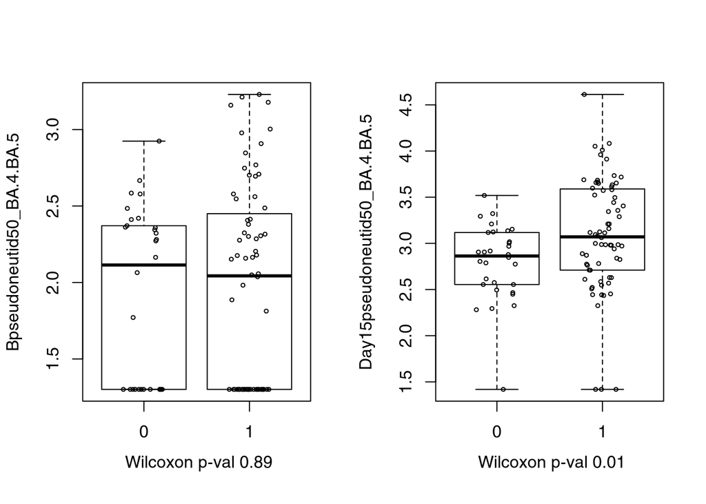

```r
par(mfrow=c(1,2))
myboxplot(Bpseudoneutid50_BA.4.BA.5~Trt, dat.1, test="w")
myboxplot(Day15pseudoneutid50_BA.4.BA.5~Trt, dat.1, test="w")
```

Additional marker models

```r
coxph(update(f, ~. + Trt + Bpseudoneutid50_D614G + Day15pseudoneutid50_D614G + I(Day15pseudoneutid50_D614G^2)), dat.1)
```

```
## Call:
## coxph(formula = update(f, ~. + Trt + Bpseudoneutid50_D614G +
##     Day15pseudoneutid50_D614G + I(Day15pseudoneutid50_D614G^2)),
##     data = dat.1)
##
##                                   coef exp(coef) se(coef)      z       p
## FOIstandardized                -0.3455    0.7079   0.3285 -1.052 0.29297
## standardized_risk_score         0.3851    1.4697   0.3798  1.014 0.31063
## Trt                            -1.3295    0.2646   0.4678 -2.842 0.00449
## Bpseudoneutid50_D614G          -0.4862    0.6150   0.4908 -0.991 0.32187
## Day15pseudoneutid50_D614G       0.7199    2.0541   9.1491  0.079 0.93729
## I(Day15pseudoneutid50_D614G^2) -0.0983    0.9064   1.0962 -0.090 0.92855
##
## Likelihood ratio test=12.1  on 6 df, p=0.05974
## n= 98, number of events= 23
```

```r
coxph(update(f, ~. + Trt + Bpseudoneutid50_D614G * Day15pseudoneutid50_D614G), dat.1)
```

```
## Call:
## coxph(formula = update(f, ~. + Trt + Bpseudoneutid50_D614G *
##     Day15pseudoneutid50_D614G), data = dat.1)
##
##                                                    coef exp(coef) se(coef)
## FOIstandardized                                 -0.3629    0.6956   0.3266
## standardized_risk_score                          0.3633    1.4380   0.3727
## Trt                                             -1.2999    0.2725   0.4475
## Bpseudoneutid50_D614G                            2.9004   18.1816   6.1345
## Day15pseudoneutid50_D614G                        2.4931   12.0987   4.7804
## Bpseudoneutid50_D614G:Day15pseudoneutid50_D614G -0.8016    0.4486   1.4502
##                                                      z       p
## FOIstandardized                                 -1.111 0.26650
## standardized_risk_score                          0.975 0.32977
## Trt                                             -2.905 0.00368
## Bpseudoneutid50_D614G                            0.473 0.63635
## Day15pseudoneutid50_D614G                        0.522 0.60200
## Bpseudoneutid50_D614G:Day15pseudoneutid50_D614G -0.553 0.58043
##
## Likelihood ratio test=12.44  on 6 df, p=0.05286
## n= 98, number of events= 23
```

```r
coxph(update(f, ~. + Trt + Bpseudoneutid50_D614G + Day15pseudoneutid50_D614G), dat.1)
```

```
## Call:
## coxph(formula = update(f, ~. + Trt + Bpseudoneutid50_D614G +
##     Day15pseudoneutid50_D614G), data = dat.1)
##
##                               coef exp(coef) se(coef)      z       p
## FOIstandardized           -0.34752   0.70644  0.32782 -1.060 0.28910
## standardized_risk_score    0.39723   1.48770  0.35421  1.121 0.26210
## Trt                       -1.34393   0.26082  0.44034 -3.052 0.00227
## Bpseudoneutid50_D614G     -0.48573   0.61525  0.49278 -0.986 0.32428
## Day15pseudoneutid50_D614G -0.09788   0.90675  0.68958 -0.142 0.88712
##
## Likelihood ratio test=12.09  on 5 df, p=0.03353
## n= 98, number of events= 23
```

```r
coxph(update(f, ~. + Trt + Bpseudoneutid50_D614G), dat.1)
```

```
## Call:
## coxph(formula = update(f, ~. + Trt + Bpseudoneutid50_D614G),
##     data = dat.1)
##
##                            coef exp(coef) se(coef)      z       p
## FOIstandardized         -0.3433    0.7094   0.3265 -1.051 0.29307
## standardized_risk_score  0.4042    1.4981   0.3542  1.141 0.25378
## Trt                     -1.3536    0.2583   0.4357 -3.106 0.00189
## Bpseudoneutid50_D614G   -0.5220    0.5934   0.4159 -1.255 0.20949
##
## Likelihood ratio test=12.07  on 4 df, p=0.01682
## n= 98, number of events= 23
```

```r
coxph(update(f, ~. + Trt + Day15pseudoneutid50_D614G), dat.1)
```

```
## Call:
## coxph(formula = update(f, ~. + Trt + Day15pseudoneutid50_D614G),
##     data = dat.1)
##
##                              coef exp(coef) se(coef)      z       p
## FOIstandardized           -0.3568    0.6999   0.3320 -1.075 0.28252
## standardized_risk_score    0.3775    1.4586   0.3485  1.083 0.27878
## Trt                       -1.3000    0.2725   0.4364 -2.979 0.00289
## Day15pseudoneutid50_D614G -0.4664    0.6273   0.5907 -0.789 0.42983
##
## Likelihood ratio test=11.21  on 4 df, p=0.02432
## n= 98, number of events= 23
```

```r
coxph(update(f, ~. + Trt + Bpseudoneutid50_BA.4.BA.5 + Day15pseudoneutid50_BA.4.BA.5 + I(Day15pseudoneutid50_BA.4.BA.5^2)), dat.1)
```

```
## Call:
## coxph(formula = update(f, ~. + Trt + Bpseudoneutid50_BA.4.BA.5 +
##     Day15pseudoneutid50_BA.4.BA.5 + I(Day15pseudoneutid50_BA.4.BA.5^2)),
##     data = dat.1)
##
##                                        coef exp(coef) se(coef)      z       p
## FOIstandardized                    -0.39082   0.67650  0.33397 -1.170 0.24192
## standardized_risk_score             0.44598   1.56201  0.35217  1.266 0.20538
## Trt                                -1.32656   0.26539  0.48196 -2.752 0.00592
## Bpseudoneutid50_BA.4.BA.5          -0.63623   0.52928  0.44876 -1.418 0.15626
## Day15pseudoneutid50_BA.4.BA.5      -0.46895   0.62566  2.24326 -0.209 0.83441
## I(Day15pseudoneutid50_BA.4.BA.5^2)  0.03931   1.04009  0.41458  0.095 0.92446
##
## Likelihood ratio test=15.12  on 6 df, p=0.01931
## n= 98, number of events= 23
```

```r
coxph(update(f, ~. + Trt + Bpseudoneutid50_BA.4.BA.5 * Day15pseudoneutid50_BA.4.BA.5), dat.1)
```

```
## Call:
## coxph(formula = update(f, ~. + Trt + Bpseudoneutid50_BA.4.BA.5 *
##     Day15pseudoneutid50_BA.4.BA.5), data = dat.1)
##
##                                                            coef exp(coef)
## FOIstandardized                                         -0.3963    0.6728
## standardized_risk_score                                  0.4624    1.5879
## Trt                                                     -1.3413    0.2615
## Bpseudoneutid50_BA.4.BA.5                               -1.5970    0.2025
## Day15pseudoneutid50_BA.4.BA.5                           -0.7192    0.4871
## Bpseudoneutid50_BA.4.BA.5:Day15pseudoneutid50_BA.4.BA.5  0.3065    1.3587
##                                                         se(coef)      z       p
## FOIstandardized                                           0.3337 -1.188 0.23499
## standardized_risk_score                                   0.3541  1.306 0.19161
## Trt                                                       0.4739 -2.830 0.00465
## Bpseudoneutid50_BA.4.BA.5                                 2.8898 -0.553 0.58053
## Day15pseudoneutid50_BA.4.BA.5                             1.4386 -0.500 0.61712
## Bpseudoneutid50_BA.4.BA.5:Day15pseudoneutid50_BA.4.BA.5   0.9028  0.340 0.73419
##
## Likelihood ratio test=15.23  on 6 df, p=0.01856
## n= 98, number of events= 23
```

```r
coxph(update(f, ~. + Trt + Bpseudoneutid50_BA.4.BA.5 + Day15pseudoneutid50_BA.4.BA.5), dat.1)
```

```
## Call:
## coxph(formula = update(f, ~. + Trt + Bpseudoneutid50_BA.4.BA.5 +
##     Day15pseudoneutid50_BA.4.BA.5), data = dat.1)
##
##                                  coef exp(coef) se(coef)      z      p
## FOIstandardized               -0.3932    0.6749   0.3327 -1.182 0.2373
## standardized_risk_score        0.4418    1.5555   0.3494  1.264 0.2061
## Trt                           -1.3153    0.2684   0.4664 -2.820 0.0048
## Bpseudoneutid50_BA.4.BA.5     -0.6318    0.5316   0.4472 -1.413 0.1577
## Day15pseudoneutid50_BA.4.BA.5 -0.2616    0.7698   0.5056 -0.517 0.6049
##
## Likelihood ratio test=15.12  on 5 df, p=0.009877
## n= 98, number of events= 23
```

```r
coxph(update(f, ~. + Trt + Bpseudoneutid50_BA.4.BA.5), dat.1)
```

```
## Call:
## coxph(formula = update(f, ~. + Trt + Bpseudoneutid50_BA.4.BA.5),
##     data = dat.1)
##
##                              coef exp(coef) se(coef)      z       p
## FOIstandardized           -0.3707    0.6903   0.3275 -1.132 0.25778
## standardized_risk_score    0.4619    1.5871   0.3584  1.289 0.19754
## Trt                       -1.4067    0.2449   0.4402 -3.196 0.00139
## Bpseudoneutid50_BA.4.BA.5 -0.7528    0.4711   0.3771 -1.996 0.04593
##
## Likelihood ratio test=14.85  on 4 df, p=0.005012
## n= 98, number of events= 23
```

```r
coxph(update(f, ~. + Trt + Day15pseudoneutid50_BA.4.BA.5), dat.1)
```

```
## Call:
## coxph(formula = update(f, ~. + Trt + Day15pseudoneutid50_BA.4.BA.5),
##     data = dat.1)
##
##                                  coef exp(coef) se(coef)      z       p
## FOIstandardized               -0.3846    0.6807   0.3365 -1.143 0.25298
## standardized_risk_score        0.3880    1.4741   0.3346  1.160 0.24613
## Trt                           -1.1710    0.3101   0.4380 -2.673 0.00751
## Day15pseudoneutid50_BA.4.BA.5 -0.6690    0.5122   0.4026 -1.661 0.09662
##
## Likelihood ratio test=13.1  on 4 df, p=0.01078
## n= 98, number of events= 23
```

#### Moderna

No treatment effect in either naive or non-naive.

```r
coxph(update(f, ~. + naive + Trt), dat.ocp.moderna)
```

```
## Call:
## coxph(formula = update(f, ~. + naive + Trt), data = dat.ocp.moderna)
##
##                            coef exp(coef) se(coef)      z       p
## FOIstandardized         -0.1298    0.8782   0.1923 -0.675 0.49956
## standardized_risk_score  0.2056    1.2283   0.1441  1.427 0.15360
## naive                    1.0871    2.9657   0.3741  2.906 0.00367
## Trt                     -0.1180    0.8887   0.2388 -0.494 0.62124
##
## Likelihood ratio test=13.62  on 4 df, p=0.008612
## n= 284, number of events= 78
```

```r
coxph(update(f, ~. + naive + Trt), subset(dat.ocp.moderna, naive==0))
```

```
## Call:
## coxph(formula = update(f, ~. + naive + Trt), data = subset(dat.ocp.moderna,
##     naive == 0))
##
##                            coef exp(coef) se(coef)      z      p
## FOIstandardized         -0.4871    0.6144   0.5445 -0.895 0.3710
## standardized_risk_score -0.4855    0.6154   0.2100 -2.312 0.0208
## naive                        NA        NA   0.0000     NA     NA
## Trt                     -0.5147    0.5977   0.7306 -0.705 0.4811
##
## Likelihood ratio test=6.87  on 3 df, p=0.07628
## n= 64, number of events= 8
```

```r
coxph(update(f, ~. + naive + Trt), subset(dat.ocp.moderna, naive==1))
```

```
## Call:
## coxph(formula = update(f, ~. + naive + Trt), data = subset(dat.ocp.moderna,
##     naive == 1))
##
##                             coef exp(coef) se(coef)      z      p
## FOIstandardized         -0.03082   0.96965  0.20833 -0.148 0.8824
## standardized_risk_score  0.45535   1.57672  0.16296  2.794 0.0052
## naive                         NA        NA  0.00000     NA     NA
## Trt                     -0.07904   0.92400  0.25598 -0.309 0.7575
##
## Likelihood ratio test=8.48  on 3 df, p=0.03705
## n= 220, number of events= 70
```

```r
dat.1.moderna=subset(dat.ocp.moderna, naive==1)
```

Distribution of D15 BA4BA5-specific ID50 is different between P and OC

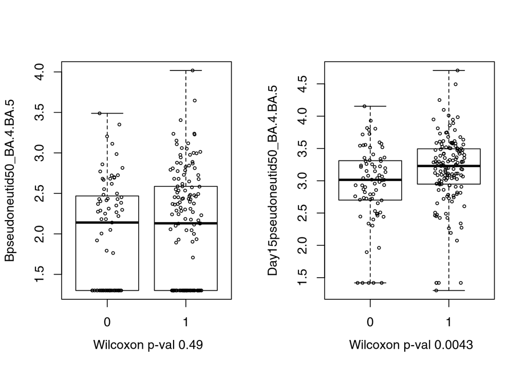

```r
par(mfrow=c(1,2))
myboxplot(Bpseudoneutid50_BA.4.BA.5~Trt, dat.1.moderna, test="w")
myboxplot(Day15pseudoneutid50_BA.4.BA.5~Trt, dat.1.moderna, test="w")
```

Among naive, there is significant interaction between Trt and D1 BA4BA5 ID50

```r
coxph(update(f, ~. + Trt * Bpseudoneutid50_BA.4.BA.5), dat.1.moderna)
```

```
## Call:
## coxph(formula = update(f, ~. + Trt * Bpseudoneutid50_BA.4.BA.5),
##     data = dat.1.moderna)
##
##                                   coef exp(coef) se(coef)      z       p
## FOIstandardized               -0.10876   0.89694  0.21194 -0.513 0.60782
## standardized_risk_score        0.51757   1.67794  0.17018  3.041 0.00236
## Trt                            1.43400   4.19546  0.80039  1.792 0.07319
## Bpseudoneutid50_BA.4.BA.5     -0.03369   0.96687  0.31280 -0.108 0.91422
## Trt:Bpseudoneutid50_BA.4.BA.5 -0.78765   0.45491  0.38980 -2.021 0.04332
##
## Likelihood ratio test=22.09  on 5 df, p=0.0005028
## n= 220, number of events= 70
```

```r
coxph(update(f, ~. + Trt + Bpseudoneutid50_BA.4.BA.5), dat.1.moderna)
```

```
## Call:
## coxph(formula = update(f, ~. + Trt + Bpseudoneutid50_BA.4.BA.5),
##     data = dat.1.moderna)
##
##                               coef exp(coef) se(coef)      z      p
## FOIstandardized           -0.08466   0.91883  0.21020 -0.403 0.6871
## standardized_risk_score    0.52343   1.68781  0.16853  3.106 0.0019
## Trt                       -0.05426   0.94719  0.25656 -0.211 0.8325
## Bpseudoneutid50_BA.4.BA.5 -0.55763   0.57256  0.18591 -3.000 0.0027
##
## Likelihood ratio test=18.02  on 4 df, p=0.001224
## n= 220, number of events= 70
```

```r
coxph(update(f, ~. + Trt * Day15pseudoneutid50_BA.4.BA.5), dat.1.moderna)
```

```
## Call:
## coxph(formula = update(f, ~. + Trt * Day15pseudoneutid50_BA.4.BA.5),
##     data = dat.1.moderna)
##
##                                        coef exp(coef)  se(coef)      z       p
## FOIstandardized                   -0.063658  0.938326  0.208384 -0.305 0.76000
## standardized_risk_score            0.419372  1.521006  0.158592  2.644 0.00818
## Trt                                2.167095  8.732879  1.238928  1.749 0.08026
## Day15pseudoneutid50_BA.4.BA.5     -0.006817  0.993206  0.346598 -0.020 0.98431
## Trt:Day15pseudoneutid50_BA.4.BA.5 -0.725744  0.483964  0.409206 -1.774 0.07614
##
## Likelihood ratio test=18.29  on 5 df, p=0.002603
## n= 220, number of events= 70
```

```r
coxph(update(f, ~. + Trt + Day15pseudoneutid50_BA.4.BA.5), dat.1.moderna)
```

```
## Call:
## coxph(formula = update(f, ~. + Trt + Day15pseudoneutid50_BA.4.BA.5),
##     data = dat.1.moderna)
##
##                                   coef exp(coef) se(coef)      z       p
## FOIstandardized               -0.04024   0.96056  0.20792 -0.194 0.84655
## standardized_risk_score        0.44264   1.55682  0.15841  2.794 0.00520
## Trt                            0.05208   1.05347  0.26166  0.199 0.84222
## Day15pseudoneutid50_BA.4.BA.5 -0.49862   0.60737  0.18590 -2.682 0.00731
##
## Likelihood ratio test=15.02  on 4 df, p=0.004658
## n= 220, number of events= 70
```

```r
coxph(update(f, ~. + Trt * Bpseudoneutid50_D614G), dat.1.moderna)
```

```
## Call:
## coxph(formula = update(f, ~. + Trt * Bpseudoneutid50_D614G),
##     data = dat.1.moderna)
##
##                               coef exp(coef) se(coef)      z       p
## FOIstandardized           -0.01409   0.98600  0.21342 -0.066 0.94734
## standardized_risk_score    0.48600   1.62579  0.16721  2.906 0.00366
## Trt                        1.57583   4.83477  1.56471  1.007 0.31388
## Bpseudoneutid50_D614G     -0.22904   0.79530  0.40054 -0.572 0.56745
## Trt:Bpseudoneutid50_D614G -0.48992   0.61268  0.46328 -1.058 0.29028
##
## Likelihood ratio test=17.22  on 5 df, p=0.004097
## n= 220, number of events= 70
```

```r
coxph(update(f, ~. + Trt + Bpseudoneutid50_D614G), dat.1.moderna)
```

```
## Call:
## coxph(formula = update(f, ~. + Trt + Bpseudoneutid50_D614G),
##     data = dat.1.moderna)
##
##                              coef exp(coef)  se(coef)      z       p
## FOIstandardized          0.005631  1.005647  0.211626  0.027 0.97877
## standardized_risk_score  0.489978  1.632280  0.166749  2.938 0.00330
## Trt                     -0.042098  0.958776  0.256407 -0.164 0.86959
## Bpseudoneutid50_D614G   -0.591856  0.553299  0.210497 -2.812 0.00493
##
## Likelihood ratio test=16.12  on 4 df, p=0.002862
## n= 220, number of events= 70
```

```r
coxph(update(f, ~. + Trt * Day15pseudoneutid50_D614G), dat.1.moderna)
```

```
## Call:
## coxph(formula = update(f, ~. + Trt * Day15pseudoneutid50_D614G),
##     data = dat.1.moderna)
##
##                                   coef exp(coef) se(coef)      z       p
## FOIstandardized               -0.04257   0.95833  0.21104 -0.202 0.84015
## standardized_risk_score        0.42967   1.53675  0.16333  2.631 0.00852
## Trt                            2.75942  15.79061  2.68283  1.029 0.30369
## Day15pseudoneutid50_D614G     -0.33609   0.71456  0.52728 -0.637 0.52386
## Trt:Day15pseudoneutid50_D614G -0.67350   0.50992  0.63901 -1.054 0.29190
##
## Likelihood ratio test=16.55  on 5 df, p=0.005445
## n= 220, number of events= 70
```

```r
coxph(update(f, ~. + Trt + Day15pseudoneutid50_D614G), dat.1.moderna)
```

```
## Call:
## coxph(formula = update(f, ~. + Trt + Day15pseudoneutid50_D614G),
##     data = dat.1.moderna)
##
##                               coef exp(coef) se(coef)      z       p
## FOIstandardized           -0.02905   0.97137  0.20991 -0.138 0.88992
## standardized_risk_score    0.43341   1.54250  0.16353  2.650 0.00804
## Trt                       -0.04242   0.95847  0.25644 -0.165 0.86862
## Day15pseudoneutid50_D614G -0.78976   0.45395  0.29689 -2.660 0.00781
##
## Likelihood ratio test=15.42  on 4 df, p=0.003899
## n= 220, number of events= 70
```

Additional marker models

```r
coxph(update(f, ~. + Trt + Bpseudoneutid50_D614G + Day15pseudoneutid50_D614G + I(Day15pseudoneutid50_D614G^2)), dat.1.moderna)
```

```
## Call:
## coxph(formula = update(f, ~. + Trt + Bpseudoneutid50_D614G +
##     Day15pseudoneutid50_D614G + I(Day15pseudoneutid50_D614G^2)),
##     data = dat.1.moderna)
##
##                                      coef  exp(coef)   se(coef)      z      p
## FOIstandardized                -5.814e-03  9.942e-01  2.114e-01 -0.028 0.9781
## standardized_risk_score         4.733e-01  1.605e+00  1.694e-01  2.794 0.0052
## Trt                            -3.537e-02  9.653e-01  2.567e-01 -0.138 0.8904
## Bpseudoneutid50_D614G          -4.341e-01  6.478e-01  2.870e-01 -1.513 0.1304
## Day15pseudoneutid50_D614G       9.463e+00  1.287e+04  6.180e+00  1.531 0.1257
## I(Day15pseudoneutid50_D614G^2) -1.195e+00  3.028e-01  7.478e-01 -1.598 0.1101
##
## Likelihood ratio test=20.2  on 6 df, p=0.00255
## n= 220, number of events= 70
```

```r
coxph(update(f, ~. + Trt + Bpseudoneutid50_D614G * Day15pseudoneutid50_D614G), dat.1.moderna)
```

```
## Call:
## coxph(formula = update(f, ~. + Trt + Bpseudoneutid50_D614G *
##     Day15pseudoneutid50_D614G), data = dat.1.moderna)
##
##                                                     coef exp(coef) se(coef)
## FOIstandardized                                 -0.02009   0.98011  0.21239
## standardized_risk_score                          0.47970   1.61559  0.16983
## Trt                                             -0.04103   0.95980  0.25641
## Bpseudoneutid50_D614G                            3.60636  36.83171  2.59976
## Day15pseudoneutid50_D614G                        2.52712  12.51740  1.94240
## Bpseudoneutid50_D614G:Day15pseudoneutid50_D614G -0.94366   0.38920  0.61038
##                                                      z       p
## FOIstandardized                                 -0.095 0.92463
## standardized_risk_score                          2.825 0.00473
## Trt                                             -0.160 0.87285
## Bpseudoneutid50_D614G                            1.387 0.16538
## Day15pseudoneutid50_D614G                        1.301 0.19325
## Bpseudoneutid50_D614G:Day15pseudoneutid50_D614G -1.546 0.12210
##
## Likelihood ratio test=19.83  on 6 df, p=0.002965
## n= 220, number of events= 70
```

```r
coxph(update(f, ~. + Trt + Bpseudoneutid50_D614G + Day15pseudoneutid50_D614G), dat.1.moderna)
```

```
## Call:
## coxph(formula = update(f, ~. + Trt + Bpseudoneutid50_D614G +
##     Day15pseudoneutid50_D614G), data = dat.1.moderna)
##
##                                coef exp(coef)  se(coef)      z      p
## FOIstandardized           -0.007339  0.992688  0.211648 -0.035 0.9723
## standardized_risk_score    0.462311  1.587738  0.167240  2.764 0.0057
## Trt                       -0.031277  0.969207  0.256769 -0.122 0.9030
## Bpseudoneutid50_D614G     -0.395893  0.673078  0.293522 -1.349 0.1774
## Day15pseudoneutid50_D614G -0.406311  0.666103  0.404493 -1.004 0.3151
##
## Likelihood ratio test=17.16  on 5 df, p=0.004213
## n= 220, number of events= 70
```

```r
coxph(update(f, ~. + Trt + Bpseudoneutid50_D614G), dat.1.moderna)
```

```
## Call:
## coxph(formula = update(f, ~. + Trt + Bpseudoneutid50_D614G),
##     data = dat.1.moderna)
##
##                              coef exp(coef)  se(coef)      z       p
## FOIstandardized          0.005631  1.005647  0.211626  0.027 0.97877
## standardized_risk_score  0.489978  1.632280  0.166749  2.938 0.00330
## Trt                     -0.042098  0.958776  0.256407 -0.164 0.86959
## Bpseudoneutid50_D614G   -0.591856  0.553299  0.210497 -2.812 0.00493
##
## Likelihood ratio test=16.12  on 4 df, p=0.002862
## n= 220, number of events= 70
```

```r
coxph(update(f, ~. + Trt + Day15pseudoneutid50_D614G), dat.1.moderna)
```

```
## Call:
## coxph(formula = update(f, ~. + Trt + Day15pseudoneutid50_D614G),
##     data = dat.1.moderna)
##
##                               coef exp(coef) se(coef)      z       p
## FOIstandardized           -0.02905   0.97137  0.20991 -0.138 0.88992
## standardized_risk_score    0.43341   1.54250  0.16353  2.650 0.00804
## Trt                       -0.04242   0.95847  0.25644 -0.165 0.86862
## Day15pseudoneutid50_D614G -0.78976   0.45395  0.29689 -2.660 0.00781
##
## Likelihood ratio test=15.42  on 4 df, p=0.003899
## n= 220, number of events= 70
```

```r
coxph(update(f, ~. + Trt + Bpseudoneutid50_BA.4.BA.5 + Day15pseudoneutid50_BA.4.BA.5 + I(Day15pseudoneutid50_BA.4.BA.5^2)), dat.1.moderna)
```

```
## Call:
## coxph(formula = update(f, ~. + Trt + Bpseudoneutid50_BA.4.BA.5 +
##     Day15pseudoneutid50_BA.4.BA.5 + I(Day15pseudoneutid50_BA.4.BA.5^2)),
##     data = dat.1.moderna)
##
##                                         coef exp(coef)  se(coef)      z       p
## FOIstandardized                     -0.16507   0.84784   0.21337 -0.774 0.43916
## standardized_risk_score              0.45693   1.57922   0.16953  2.695 0.00703
## Trt                                  0.09869   1.10373   0.26505  0.372 0.70963
## Bpseudoneutid50_BA.4.BA.5           -0.18224   0.83340   0.24952 -0.730 0.46517
## Day15pseudoneutid50_BA.4.BA.5        4.87481 130.94983   1.87375  2.602 0.00928
## I(Day15pseudoneutid50_BA.4.BA.5^2)  -0.97889   0.37573   0.34700 -2.821 0.00479
##
## Likelihood ratio test=29.29  on 6 df, p=5.372e-05
## n= 220, number of events= 70
```

```r
coxph(update(f, ~. + Trt + Bpseudoneutid50_BA.4.BA.5 * Day15pseudoneutid50_BA.4.BA.5), dat.1.moderna)
```

```
## Call:
## coxph(formula = update(f, ~. + Trt + Bpseudoneutid50_BA.4.BA.5 *
##     Day15pseudoneutid50_BA.4.BA.5), data = dat.1.moderna)
##
##                                                              coef exp(coef)
## FOIstandardized                                          -0.13156   0.87673
## standardized_risk_score                                   0.45336   1.57359
## Trt                                                       0.04978   1.05104
## Bpseudoneutid50_BA.4.BA.5                                 5.66331 288.10120
## Day15pseudoneutid50_BA.4.BA.5                             2.57487  13.12966
## Bpseudoneutid50_BA.4.BA.5:Day15pseudoneutid50_BA.4.BA.5  -1.87482   0.15338
##                                                          se(coef)      z
## FOIstandardized                                           0.21151 -0.622
## standardized_risk_score                                   0.16885  2.685
## Trt                                                       0.26683  0.187
## Bpseudoneutid50_BA.4.BA.5                                 1.70177  3.328
## Day15pseudoneutid50_BA.4.BA.5                             0.84488  3.048
## Bpseudoneutid50_BA.4.BA.5:Day15pseudoneutid50_BA.4.BA.5   0.53345 -3.515
##                                                                p
## FOIstandardized                                         0.533957
## standardized_risk_score                                 0.007252
## Trt                                                     0.851993
## Bpseudoneutid50_BA.4.BA.5                               0.000875
## Day15pseudoneutid50_BA.4.BA.5                           0.002307
## Bpseudoneutid50_BA.4.BA.5:Day15pseudoneutid50_BA.4.BA.5 0.000441
##
## Likelihood ratio test=32.41  on 6 df, p=1.363e-05
## n= 220, number of events= 70
```

```r
coxph(update(f, ~. + Trt + Bpseudoneutid50_BA.4.BA.5 + Day15pseudoneutid50_BA.4.BA.5), dat.1.moderna)
```

```
## Call:
## coxph(formula = update(f, ~. + Trt + Bpseudoneutid50_BA.4.BA.5 +
##     Day15pseudoneutid50_BA.4.BA.5), data = dat.1.moderna)
##
##                                    coef exp(coef)  se(coef)      z       p
## FOIstandardized               -0.076829  0.926048  0.209936 -0.366 0.71439
## standardized_risk_score        0.501798  1.651689  0.167333  2.999 0.00271
## Trt                           -0.002618  0.997386  0.264350 -0.010 0.99210
## Bpseudoneutid50_BA.4.BA.5     -0.445376  0.640583  0.233371 -1.908 0.05633
## Day15pseudoneutid50_BA.4.BA.5 -0.201700  0.817340  0.246766 -0.817 0.41371
##
## Likelihood ratio test=18.67  on 5 df, p=0.002214
## n= 220, number of events= 70
```

```r
coxph(update(f, ~. + Trt + Bpseudoneutid50_BA.4.BA.5), dat.1.moderna)
```

```
## Call:
## coxph(formula = update(f, ~. + Trt + Bpseudoneutid50_BA.4.BA.5),
##     data = dat.1.moderna)
##
##                               coef exp(coef) se(coef)      z      p
## FOIstandardized           -0.08466   0.91883  0.21020 -0.403 0.6871
## standardized_risk_score    0.52343   1.68781  0.16853  3.106 0.0019
## Trt                       -0.05426   0.94719  0.25656 -0.211 0.8325
## Bpseudoneutid50_BA.4.BA.5 -0.55763   0.57256  0.18591 -3.000 0.0027
##
## Likelihood ratio test=18.02  on 4 df, p=0.001224
## n= 220, number of events= 70
```

```r
coxph(update(f, ~. + Trt + Day15pseudoneutid50_BA.4.BA.5), dat.1.moderna)
```

```
## Call:
## coxph(formula = update(f, ~. + Trt + Day15pseudoneutid50_BA.4.BA.5),
##     data = dat.1.moderna)
##
##                                   coef exp(coef) se(coef)      z       p
## FOIstandardized               -0.04024   0.96056  0.20792 -0.194 0.84655
## standardized_risk_score        0.44264   1.55682  0.15841  2.794 0.00520
## Trt                            0.05208   1.05347  0.26166  0.199 0.84222
## Day15pseudoneutid50_BA.4.BA.5 -0.49862   0.60737  0.18590 -2.682 0.00731
##
## Likelihood ratio test=15.02  on 4 df, p=0.004658
## n= 220, number of events= 70
```

```r
coxph(update(f, ~.  + Day15pseudoneutid50_D614G), subset(dat.1.moderna, Trt==1))
```

```
## Call:
## coxph(formula = update(f, ~. + Day15pseudoneutid50_D614G), data = subset(dat.1.moderna,
##     Trt == 1))
##
##                              coef exp(coef) se(coef)      z       p
## FOIstandardized           -0.1406    0.8688   0.2749 -0.512 0.60893
## standardized_risk_score    0.5205    1.6829   0.1945  2.676 0.00745
## Day15pseudoneutid50_D614G -1.0358    0.3549   0.3641 -2.845 0.00444
##
## Likelihood ratio test=17.49  on 3 df, p=0.000561
## n= 145, number of events= 47
```

```r
coxph(update(f, ~.  + Day15pseudoneutid50_D614G), subset(dat.1.moderna, Trt==0))
```

```
## Call:
## coxph(formula = update(f, ~. + Day15pseudoneutid50_D614G), data = subset(dat.1.moderna,
##     Trt == 0))
##
##                              coef exp(coef) se(coef)      z     p
## FOIstandardized            0.1887    1.2077   0.3398  0.555 0.579
## standardized_risk_score    0.1503    1.1622   0.2951  0.509 0.610
## Day15pseudoneutid50_D614G -0.3670    0.6928   0.5321 -0.690 0.490
##
## Likelihood ratio test=1.13  on 3 df, p=0.7695
## n= 75, number of events= 23
```

#### Putting Pfizer and Moderna side by side

Omicron-specific antibodies are similar at D1, rise at D15, and more so when vaccines contain Omicron strains.

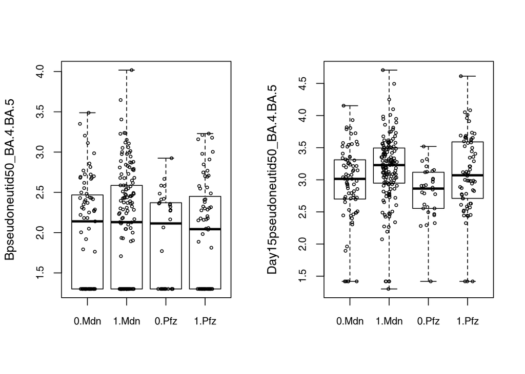

```r
par(mfrow=c(1,2))
myboxplot(Bpseudoneutid50_BA.4.BA.5~Trt+company, subset(dat.ocp, naive==1), cex.axis=.8)
myboxplot(Day15pseudoneutid50_BA.4.BA.5~Trt+company, subset(dat.ocp, naive==1), cex.axis=.8)
```

Ancestral antibodies are not quite similar at D1, rise at D15, but not more so when vaccines contain Omicron strains.

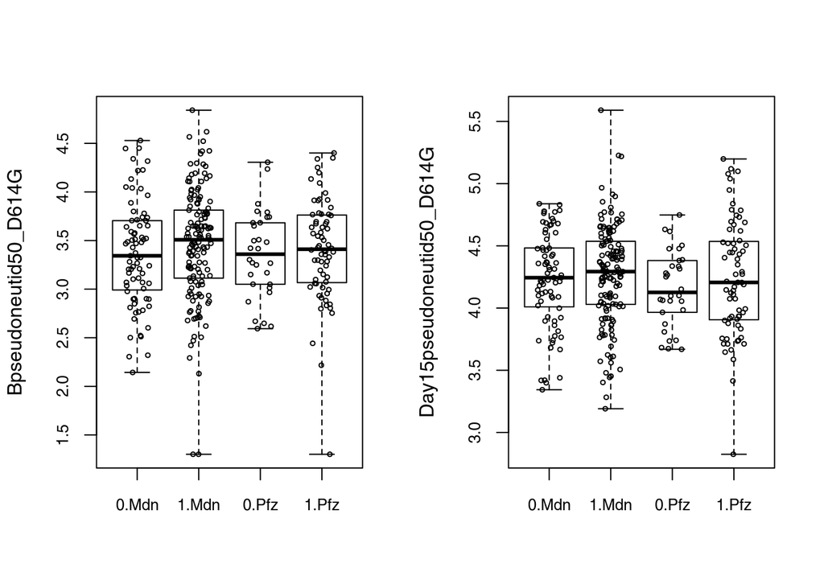

```r
par(mfrow=c(1,2))
myboxplot(Bpseudoneutid50_D614G~Trt+company, subset(dat.ocp, naive==1), cex.axis=.8)
myboxplot(Day15pseudoneutid50_D614G~Trt+company, subset(dat.ocp, naive==1), cex.axis=.8)
```

```r
fits=list()
fits[["Pfz,P"]] = coxph(update(f, ~.  + Day15pseudoneutid50_D614G), subset(dat.ocp, naive==1 & company=="Pfz" & Trt==0))
fits[["Pfz,O"]] = coxph(update(f, ~.  + Day15pseudoneutid50_D614G), subset(dat.ocp, naive==1 & company=="Pfz" & Trt==1))
fits[["Mdn,P"]] = coxph(update(f, ~.  + Day15pseudoneutid50_D614G), subset(dat.ocp, naive==1 & company=="Mdn" & Trt==0))
fits[["Mdn,O"]] = coxph(update(f, ~.  + Day15pseudoneutid50_D614G), subset(dat.ocp, naive==1 & company=="Mdn" & Trt==1))
tab = getFormattedSummary(fits, robust=F, type=5)
tab
```

```
##                           Pfz,P   Pfz,O   Mdn,P   Mdn,O
## FOIstandardized           "-0.49" "-0.22" "0.19"  "-0.14"
## standardized_risk_score   "0.36"  "0.36"  "0.15"  "0.52**"
## Day15pseudoneutid50_D614G "-0.15" "-0.70" "-0.37" "-1.04**"
```

Are risk scores distribution different?

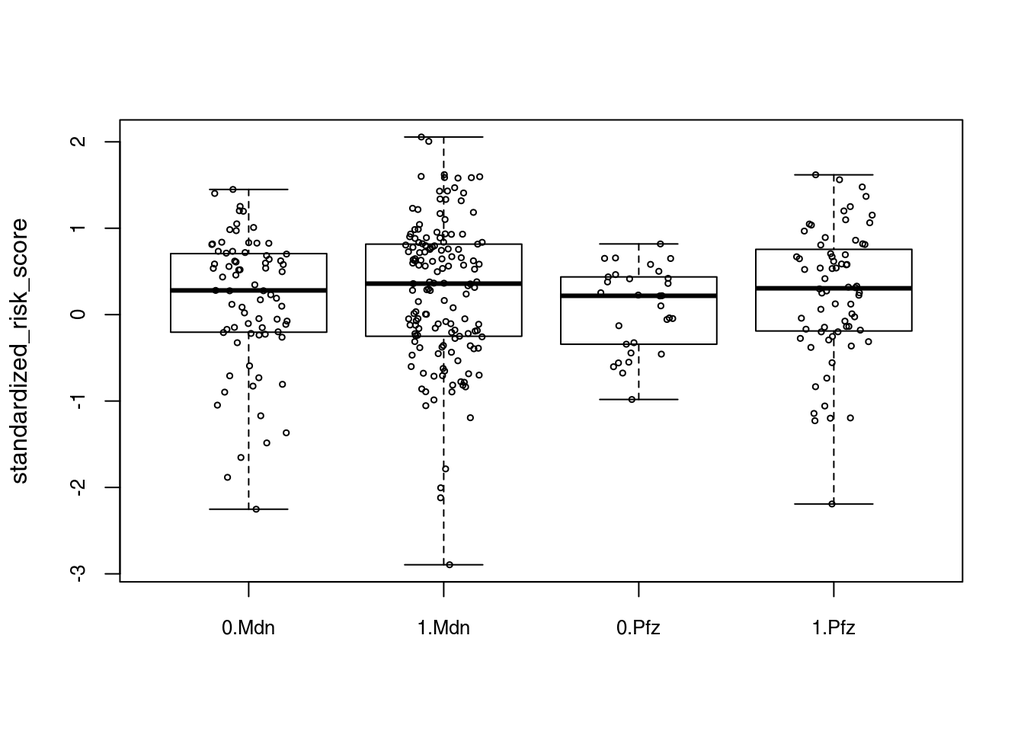

```r
myboxplot(standardized_risk_score    ~Trt+company, subset(dat.ocp, naive==1), cex.axis=.8)
```

```r
coxph(Surv(COVIDtimeD22toD181, COVIDIndD22toD181) ~ standardized_risk_score*Trt, subset(dat.ocp, naive==1 & company=="Mdn"))
```

```
## Call:
## coxph(formula = Surv(COVIDtimeD22toD181, COVIDIndD22toD181) ~
##     standardized_risk_score * Trt, data = subset(dat.ocp, naive ==
##     1 & company == "Mdn"))
##
##                                coef exp(coef) se(coef)      z     p
## standardized_risk_score      0.1836    1.2015   0.2949  0.623 0.534
## Trt                         -0.2121    0.8089   0.2839 -0.747 0.455
## standardized_risk_score:Trt  0.3793    1.4613   0.3523  1.077 0.282
##
## Likelihood ratio test=9.58  on 3 df, p=0.02251
## n= 220, number of events= 70
```

BA4BA5 marker. Three out of the four effect sizes are comparable to each other, but in the Moderna prototype arm there is no association between BA4BA5 marker and risk. This is quite intriguing - if we view each column above as a correlates analysis, we have three positive results and one negative result.

```r
fits=list()
fits[["Pfz,P"]] = coxph(update(f, ~.  + Day15pseudoneutid50_BA.4.BA.5), subset(dat.ocp, naive==1 & company=="Pfz" & Trt==0))
fits[["Pfz,O"]] = coxph(update(f, ~.  + Day15pseudoneutid50_BA.4.BA.5), subset(dat.ocp, naive==1 & company=="Pfz" & Trt==1))
fits[["Mdn,P"]] = coxph(update(f, ~.  + Day15pseudoneutid50_BA.4.BA.5), subset(dat.ocp, naive==1 & company=="Mdn" & Trt==0))
fits[["Mdn,O"]] = coxph(update(f, ~.  + Day15pseudoneutid50_BA.4.BA.5), subset(dat.ocp, naive==1 & company=="Mdn" & Trt==1))
tab = getFormattedSummary(fits, robust=F, type=5)
tab
```

```
##                               Pfz,P   Pfz,O   Mdn,P  Mdn,O
## FOIstandardized               "-0.51" "-0.29" "0.17" "-0.16"
## standardized_risk_score       "0.25"  "0.44"  "0.16" "0.50**"
## Day15pseudoneutid50_BA.4.BA.5 "-0.62" "-0.75" "0.00" "-0.76**"
```

### Risk models

ID50 Score

```r
dat$D1_id50=scale(dat$Bpseudoneutid50_MDW,scale=F)
dat$Day15_id50=scale(dat$Day15pseudoneutid50_MDW,scale=F)

coxph(Surv(COVIDtimeD22toD181, COVIDIndD22toD181) ~ FOIstandardized + standardized_risk_score + naive + Day15_id50, dat)
```

```
## Call:
## coxph(formula = Surv(COVIDtimeD22toD181, COVIDIndD22toD181) ~
##     FOIstandardized + standardized_risk_score + naive + Day15_id50,
##     data = dat)
##
##                              coef exp(coef)  se(coef)      z        p
## FOIstandardized          0.001851  1.001853  0.082550  0.022  0.98211
## standardized_risk_score  0.220804  1.247079  0.084345  2.618  0.00885
## naive                    1.054369  2.870165  0.210874  5.000 5.73e-07
## Day15_id50              -0.371085  0.689986  0.134860 -2.752  0.00593
##
## Likelihood ratio test=77.26  on 4 df, p=6.61e-16
## n= 985, number of events= 213
```

```r
coxph(Surv(COVIDtimeD22toD181, COVIDIndD22toD181) ~ standardized_risk_score + naive + D1_id50 + Day15_id50 + I(Day15_id50^2), dat)
```

```
## Call:
## coxph(formula = Surv(COVIDtimeD22toD181, COVIDIndD22toD181) ~
##     standardized_risk_score + naive + D1_id50 + Day15_id50 +
##         I(Day15_id50^2), data = dat)
##
##                             coef exp(coef) se(coef)      z        p
## standardized_risk_score  0.24172   1.27343  0.08176  2.956 0.003112
## naive                    0.66527   1.94501  0.22308  2.982 0.002862
## D1_id50                 -0.44490   0.64089  0.16269 -2.735 0.006245
## Day15_id50              -0.49043   0.61236  0.25055 -1.957 0.050294
## I(Day15_id50^2)         -0.98915   0.37189  0.27479 -3.600 0.000319
##
## Likelihood ratio test=103.4  on 5 df, p=< 2.2e-16
## n= 985, number of events= 213
```

```r
coxph(Surv(COVIDtimeD22toD181, COVIDIndD22toD181) ~ standardized_risk_score + naive + naive*(D1_id50 + Day15_id50 + I(Day15_id50^2)), dat)
```

```
## Call:
## coxph(formula = Surv(COVIDtimeD22toD181, COVIDIndD22toD181) ~
##     standardized_risk_score + naive + naive * (D1_id50 + Day15_id50 +
##         I(Day15_id50^2)), data = dat)
##
##                             coef exp(coef) se(coef)      z       p
## standardized_risk_score  0.23644   1.26673  0.08174  2.892 0.00382
## naive                    0.56240   1.75488  0.22961  2.449 0.01431
## D1_id50                 -0.91307   0.40129  0.36906 -2.474 0.01336
## Day15_id50              -0.76230   0.46659  0.56949 -1.339 0.18071
## I(Day15_id50^2)         -0.75581   0.46963  0.46669 -1.620 0.10534
## naive:D1_id50            0.56603   1.76126  0.40890  1.384 0.16628
## naive:Day15_id50         0.33588   1.39917  0.63396  0.530 0.59624
## naive:I(Day15_id50^2)   -0.13493   0.87377  0.55767 -0.242 0.80881
##
## Likelihood ratio test=108  on 8 df, p=< 2.2e-16
## n= 985, number of events= 213
```

```r
coxph(Surv(COVIDtimeD22toD181, COVIDIndD22toD181) ~ standardized_risk_score + naive + naive*D1_id50 + Day15_id50 + I(Day15_id50^2), dat)
```

```
## Call:
## coxph(formula = Surv(COVIDtimeD22toD181, COVIDIndD22toD181) ~
##     standardized_risk_score + naive + naive * D1_id50 + Day15_id50 +
##         I(Day15_id50^2), data = dat)
##
##                             coef exp(coef) se(coef)      z        p
## standardized_risk_score  0.23504   1.26496  0.08166  2.878 0.003998
## naive                    0.53717   1.71115  0.21176  2.537 0.011192
## D1_id50                 -1.02753   0.35789  0.30465 -3.373 0.000744
## Day15_id50              -0.47621   0.62113  0.24694 -1.928 0.053804
## I(Day15_id50^2)         -0.88168   0.41409  0.26717 -3.300 0.000966
## naive:D1_id50            0.70604   2.02595  0.32593  2.166 0.030292
##
## Likelihood ratio test=107.7  on 6 df, p=< 2.2e-16
## n= 985, number of events= 213
```

```r
coxph(Surv(COVIDtimeD22toD181, COVIDIndD22toD181) ~ standardized_risk_score + naive + D1_id50 + naive*Day15_id50 + naive*I(Day15_id50^2), dat)
```

```
## Call:
## coxph(formula = Surv(COVIDtimeD22toD181, COVIDIndD22toD181) ~
##     standardized_risk_score + naive + D1_id50 + naive * Day15_id50 +
##         naive * I(Day15_id50^2), data = dat)
##
##                             coef exp(coef) se(coef)      z       p
## standardized_risk_score  0.24273   1.27472  0.08174  2.969 0.00298
## naive                    0.63995   1.89639  0.23269  2.750 0.00596
## D1_id50                 -0.44191   0.64281  0.16069 -2.750 0.00596
## Day15_id50              -1.19176   0.30368  0.48297 -2.468 0.01360
## I(Day15_id50^2)         -0.75693   0.46911  0.45572 -1.661 0.09673
## naive:Day15_id50         0.84626   2.33092  0.51659  1.638 0.10139
## naive:I(Day15_id50^2)   -0.14280   0.86693  0.54910 -0.260 0.79482
##
## Likelihood ratio test=106.2  on 7 df, p=< 2.2e-16
## n= 985, number of events= 213
```

```r
coxph(Surv(COVIDtimeD22toD181, COVIDIndD22toD181) ~ standardized_risk_score + naive + D1_id50 + Day15_id50 + naive*I(Day15_id50^2), dat)
```

```
## Call:
## coxph(formula = Surv(COVIDtimeD22toD181, COVIDIndD22toD181) ~
##     standardized_risk_score + naive + D1_id50 + Day15_id50 +
##         naive * I(Day15_id50^2), data = dat)
##
##                             coef exp(coef) se(coef)      z       p
## standardized_risk_score  0.24081   1.27228  0.08177  2.945 0.00323
## naive                    0.70910   2.03216  0.24324  2.915 0.00355
## D1_id50                 -0.44461   0.64108  0.16272 -2.732 0.00629
## Day15_id50              -0.52303   0.59272  0.26075 -2.006 0.04487
## I(Day15_id50^2)         -0.70683   0.49321  0.62738 -1.127 0.25990
## naive:I(Day15_id50^2)   -0.34038   0.71150  0.71376 -0.477 0.63345
##
## Likelihood ratio test=103.6  on 6 df, p=< 2.2e-16
## n= 985, number of events= 213
```

```r
coxph(Surv(COVIDtimeD22toD181, COVIDIndD22toD181) ~ standardized_risk_score + naive + D1_id50 + naive*Day15_id50 + I(Day15_id50^2), dat)
```

```
## Call:
## coxph(formula = Surv(COVIDtimeD22toD181, COVIDIndD22toD181) ~
##     standardized_risk_score + naive + D1_id50 + naive * Day15_id50 +
##         I(Day15_id50^2), data = dat)
##
##                             coef exp(coef) se(coef)      z       p
## standardized_risk_score  0.24300   1.27507  0.08171  2.974 0.00294
## naive                    0.61857   1.85626  0.21646  2.858 0.00427
## D1_id50                 -0.44083   0.64350  0.16055 -2.746 0.00604
## Day15_id50              -1.21649   0.29627  0.48543 -2.506 0.01221
## I(Day15_id50^2)         -0.86024   0.42306  0.26191 -3.285 0.00102
## naive:Day15_id50         0.88834   2.43109  0.50261  1.767 0.07715
##
## Likelihood ratio test=106.2  on 6 df, p=< 2.2e-16
## n= 985, number of events= 213
```

ID50 BA4BA5

```r
dat$D1_id50=scale(dat$Bpseudoneutid50_BA.4.BA.5,scale=F)
dat$Day15_id50=scale(dat$Day15pseudoneutid50_BA.4.BA.5,scale=F)

coxph(Surv(COVIDtimeD22toD181, COVIDIndD22toD181) ~ standardized_risk_score + naive + naive*D1_id50 + Day15_id50 + I(Day15_id50^2), dat)
```

```
## Call:
## coxph(formula = Surv(COVIDtimeD22toD181, COVIDIndD22toD181) ~
##     standardized_risk_score + naive + naive * D1_id50 + Day15_id50 +
##         I(Day15_id50^2), data = dat)
##
##                            coef exp(coef) se(coef)      z       p
## standardized_risk_score  0.2190    1.2448   0.0811  2.700 0.00694
## naive                    0.4651    1.5921   0.2136  2.177 0.02946
## D1_id50                 -0.9630    0.3818   0.2799 -3.441 0.00058
## Day15_id50              -0.4177    0.6586   0.2126 -1.964 0.04948
## I(Day15_id50^2)         -0.4346    0.6475   0.1563 -2.779 0.00545
## naive:D1_id50            0.6896    1.9930   0.2910  2.370 0.01779
##
## Likelihood ratio test=106.1  on 6 df, p=< 2.2e-16
## n= 985, number of events= 213
```

```r
# filter out those with undetectable D1
coxph(Surv(COVIDtimeD22toD181, COVIDIndD22toD181) ~ standardized_risk_score + naive + naive*D1_id50 + Day15_id50 + I(Day15_id50^2), subset(dat, D1_id50 > -1.06))
```

```
## Call:
## coxph(formula = Surv(COVIDtimeD22toD181, COVIDIndD22toD181) ~
##     standardized_risk_score + naive + naive * D1_id50 + Day15_id50 +
##         I(Day15_id50^2), data = subset(dat, D1_id50 > -1.06))
##
##                            coef exp(coef) se(coef)      z      p
## standardized_risk_score  0.0757    1.0786   0.1045  0.724 0.4688
## naive                    0.4559    1.5776   0.3107  1.467 0.1423
## D1_id50                 -0.9408    0.3903   0.4848 -1.941 0.0523
## Day15_id50              -0.6463    0.5240   0.2964 -2.180 0.0292
## I(Day15_id50^2)         -0.6404    0.5271   0.3936 -1.627 0.1037
## naive:D1_id50            0.8220    2.2751   0.5404  1.521 0.1282
##
## Likelihood ratio test=63.51  on 6 df, p=8.688e-12
## n= 699, number of events= 117
```

```r
# fit model to get inference for D1_id50 in the naive
coxph(Surv(COVIDtimeD22toD181, COVIDIndD22toD181) ~ standardized_risk_score + I(1-naive)*D1_id50 + Day15_id50 + I(Day15_id50^2), dat)
```

```
## Call:
## coxph(formula = Surv(COVIDtimeD22toD181, COVIDIndD22toD181) ~
##     standardized_risk_score + I(1 - naive) * D1_id50 + Day15_id50 +
##         I(Day15_id50^2), data = dat)
##
##                            coef exp(coef) se(coef)      z       p
## standardized_risk_score  0.2190    1.2448   0.0811  2.700 0.00694
## I(1 - naive)            -0.4651    0.6281   0.2136 -2.177 0.02946
## D1_id50                 -0.2733    0.7608   0.1396 -1.958 0.05027
## Day15_id50              -0.4177    0.6586   0.2126 -1.964 0.04948
## I(Day15_id50^2)         -0.4346    0.6475   0.1563 -2.779 0.00545
## I(1 - naive):D1_id50    -0.6896    0.5018   0.2910 -2.370 0.01779
##
## Likelihood ratio test=106.1  on 6 df, p=< 2.2e-16
## n= 985, number of events= 213
```

```r
# filter out those with undetectable D1
coxph(Surv(COVIDtimeD22toD181, COVIDIndD22toD181) ~ standardized_risk_score + I(1-naive)*D1_id50 + Day15_id50 + I(Day15_id50^2), subset(dat, D1_id50 > -1.06))
```

```
## Call:
## coxph(formula = Surv(COVIDtimeD22toD181, COVIDIndD22toD181) ~
##     standardized_risk_score + I(1 - naive) * D1_id50 + Day15_id50 +
##         I(Day15_id50^2), data = subset(dat, D1_id50 > -1.06))
##
##                            coef exp(coef) se(coef)      z      p
## standardized_risk_score  0.0757    1.0786   0.1045  0.724 0.4688
## I(1 - naive)            -0.4559    0.6339   0.3107 -1.467 0.1423
## D1_id50                 -0.1188    0.8880   0.3228 -0.368 0.7128
## Day15_id50              -0.6463    0.5240   0.2964 -2.180 0.0292
## I(Day15_id50^2)         -0.6404    0.5271   0.3936 -1.627 0.1037
## I(1 - naive):D1_id50    -0.8220    0.4395   0.5404 -1.521 0.1282
##
## Likelihood ratio test=63.51  on 6 df, p=8.688e-12
## n= 699, number of events= 117
```

The effect of risk score is different between models with and without double naive (naive and with undetectable D1_id50).

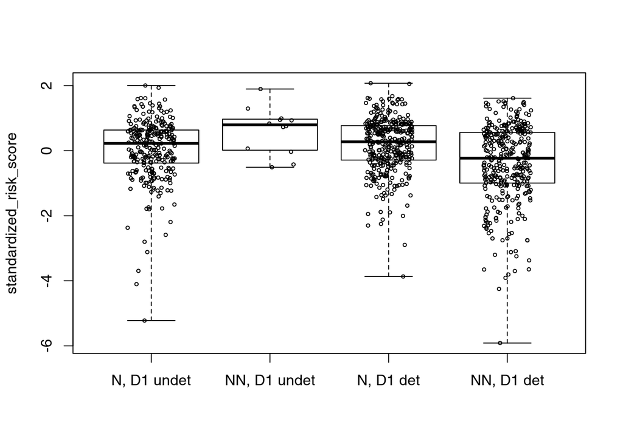

```r
dat$D1_id50=scale(dat$Bpseudoneutid50_BA.4.BA.5,scale=F)

myboxplot(standardized_risk_score~I(1-naive)*I(D1_id50 > -1.06), dat, ylab="standardized_risk_score", names=c("N, D1 undet", "NN, D1 undet", "N, D1 det", "NN, D1 det"))
```

```r
fit=lm(standardized_risk_score ~ I(1-naive) * I(D1_id50 > -1.06), dat); summary(fit)
```

```
##
## Call:
## lm(formula = standardized_risk_score ~ I(1 - naive) * I(D1_id50 >
##     -1.06), data = dat)
##
## Residuals:
##     Min      1Q  Median      3Q     Max
## -5.5176 -0.5421  0.1354  0.6626  2.0105
##
## Coefficients:
##                                     Estimate Std. Error t value Pr(>|t|)
## (Intercept)                          0.03930    0.06026   0.652 0.514516
## I(1 - naive)                         0.58424    0.29421   1.986 0.047336 *
## I(D1_id50 > -1.06)TRUE               0.13356    0.08022   1.665 0.096237 .
## I(1 - naive):I(D1_id50 > -1.06)TRUE -1.15269    0.30374  -3.795 0.000157 ***
## ---
## Signif. codes:  0 '***' 0.001 '**' 0.01 '*' 0.05 '.' 0.1 ' ' 1
##
## Residual standard error: 0.9976 on 981 degrees of freedom
## Multiple R-squared:  0.06359,    Adjusted R-squared:  0.06073
## F-statistic: 22.21 on 3 and 981 DF,  p-value: 6.459e-14
```

```r
fit=lm(standardized_risk_score ~ I(1-naive), subset(dat, D1_id50 <= -1.06)); summary(fit)
```

```
##
## Call:
## lm(formula = standardized_risk_score ~ I(1 - naive), data = subset(dat,
##     D1_id50 <= -1.06))
##
## Residuals:
##     Min      1Q  Median      3Q     Max
## -5.2614 -0.4698  0.1859  0.5916  1.9658
##
## Coefficients:
##              Estimate Std. Error t value Pr(>|t|)
## (Intercept)    0.0393     0.0567   0.693   0.4888
## I(1 - naive)   0.5842     0.2768   2.111   0.0357 *
## ---
## Signif. codes:  0 '***' 0.001 '**' 0.01 '*' 0.05 '.' 0.1 ' ' 1
##
## Residual standard error: 0.9385 on 284 degrees of freedom
## Multiple R-squared:  0.01545,    Adjusted R-squared:  0.01198
## F-statistic: 4.455 on 1 and 284 DF,  p-value: 0.03566
```

```r
f=Surv(COVIDtimeD22toD181, COVIDIndD22toD181) ~ FOIstandardized + standardized_risk_score

dat.ocp=subset(dat_proc, ph1.D15==1 & treatment_assigned %in% c(
    "Wildtype/Prototype (Pfizer 1)"
  , "Omicron (Pfizer 1)"
  , "Omicron + Wildtype/Prototype (Pfizer 1)"
  # , "Omicron BA.4/5 + Prototype (Pfizer 2)"
  # , "Omicron BA.1 + Prototype (Pfizer 2)"
  )
)
dat.ocp$Trt=ifelse(dat.ocp$treatment_assigned == "Wildtype/Prototype (Pfizer 1)", 0, 1)

coxph(update(f, ~. + naive + Trt), dat.ocp)
```

```
## Call:
## coxph(formula = update(f, ~. + naive + Trt), data = dat.ocp)
##
##                            coef exp(coef) se(coef)      z       p
## FOIstandardized         -0.1126    0.8935   0.2984 -0.377 0.70591
## standardized_risk_score  0.2795    1.3224   0.2878  0.971 0.33154
## naive                    0.8310    2.2955   0.4551  1.826 0.06787
## Trt                     -1.1399    0.3199   0.3749 -3.040 0.00236
##
## Likelihood ratio test=12.14  on 4 df, p=0.01631
## n= 151, number of events= 30
```

```r
coxph(update(f, ~. + naive + Trt), subset(dat.ocp, naive==0))
```

```
## Call:
## coxph(formula = update(f, ~. + naive + Trt), data = subset(dat.ocp,
##     naive == 0))
##
##                             coef exp(coef) se(coef)      z     p
## FOIstandardized          0.59531   1.81359  0.61480  0.968 0.333
## standardized_risk_score  0.04664   1.04775  0.52826  0.088 0.930
## naive                         NA        NA  0.00000     NA    NA
## Trt                     -0.52997   0.58862  0.77255 -0.686 0.493
##
## Likelihood ratio test=1.38  on 3 df, p=0.7098
## n= 53, number of events= 7
```

```r
coxph(update(f, ~. + naive + Trt), subset(dat.ocp, naive==1))
```

```
## Call:
## coxph(formula = update(f, ~. + naive + Trt), data = subset(dat.ocp,
##     naive == 1))
##
##                            coef exp(coef) se(coef)      z      p
## FOIstandardized         -0.3243    0.7231   0.3318 -0.977 0.3285
## standardized_risk_score  0.4130    1.5113   0.3592  1.150 0.2503
## naive                        NA        NA   0.0000     NA     NA
## Trt                     -1.3346    0.2633   0.4359 -3.062 0.0022
##
## Likelihood ratio test=10.59  on 3 df, p=0.01415
## n= 98, number of events= 23
```

```r
dat.1=subset(dat.ocp, naive==1)
```

### B and D15 marker

```r
table(dat$Bpseudoneutid50_MDWcat, dat$Day15pseudoneutid50_MDWcat)
```

```
##
##               (-Inf,3.62] (3.62,4.07] (4.07, Inf]
##   (-Inf,2.56]         228          80          20
##   (2.56,3.27]          94         155          80
##   (3.27, Inf]           6          94         228
```

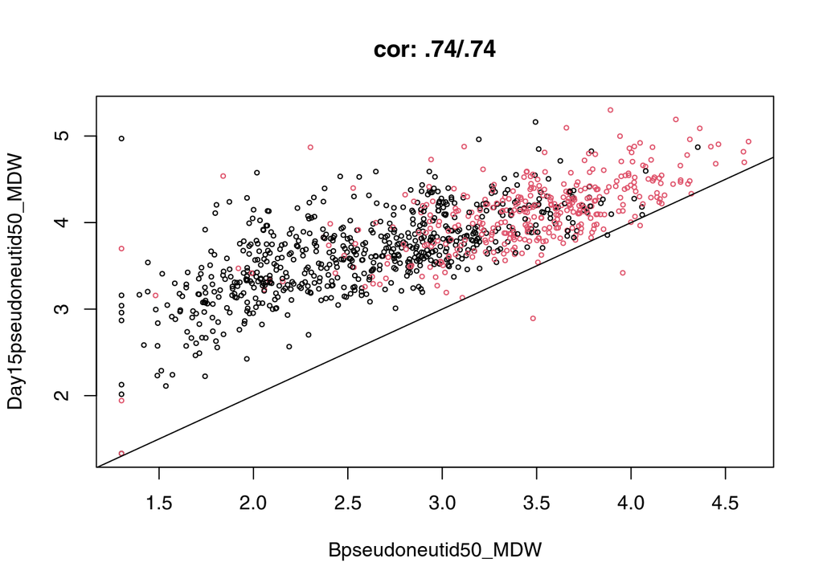

```r
corplot(Day15pseudoneutid50_MDW~Bpseudoneutid50_MDW, dat, col=ifelse(dat$naive==1,1,2))
```

```r
# fit demming regression
dat.n=subset(dat, naive==1)
dat.nn=subset(dat, naive==0)

fit.n =  Deming(dat.n$Bpseudoneutid50_MDW,  dat.n$Day15pseudoneutid50_MDW,  boot = TRUE)
fit.nn = Deming(dat.nn$Bpseudoneutid50_MDW, dat.nn$Day15pseudoneutid50_MDW, boot = TRUE)

summary(fit.n)
```

```
##                                           est    se(est)    (lower    upper)
## Intercept                           1.7871909 0.09110302 1.6060820 1.9576747
## Slope                               0.7210016 0.03387975 0.6587173 0.7917871
## sigma.dat.n$Bpseudoneutid50_MDW     0.2985262 0.01199177 0.2758940 0.3226616
## sigma.dat.n$Day15pseudoneutid50_MDW 0.2985262 0.01199177 0.2758940 0.3226616
##                                           p.value
## Intercept                            1.101506e-85
## Slope                               1.695729e-100
## sigma.dat.n$Bpseudoneutid50_MDW     8.584826e-137
## sigma.dat.n$Day15pseudoneutid50_MDW 8.584826e-137
```

```r
summary(fit.nn)
```

```
##                                            est    se(est)    (lower    upper)
## Intercept                            1.5126849 0.23922704 1.0462625 1.9694045
## Slope                                0.7497295 0.06739409 0.6212233 0.8797335
## sigma.dat.nn$Bpseudoneutid50_MDW     0.2761024 0.01648200 0.2426575 0.3060327
## sigma.dat.nn$Day15pseudoneutid50_MDW 0.2761024 0.01648200 0.2426575 0.3060327
##                                           p.value
## Intercept                            2.561708e-10
## Slope                                9.527661e-29
## sigma.dat.nn$Bpseudoneutid50_MDW     5.497849e-63
## sigma.dat.nn$Day15pseudoneutid50_MDW 5.497849e-63
```

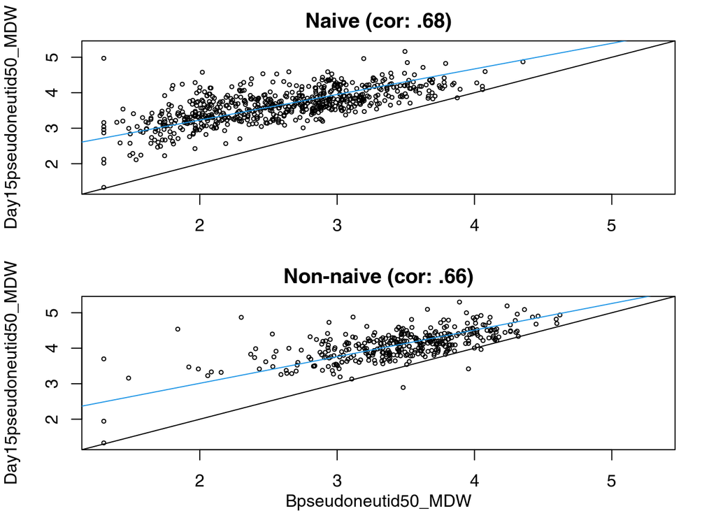

```r
par(mfrow=c(2,1), mar=c(3,4,2,2))
lim=range(c(dat$Bpseudoneutid50_MDW, dat$Day15pseudoneutid50_MDW))
corplot(Day15pseudoneutid50_MDW~Bpseudoneutid50_MDW, dat.n, add.deming.fit = T, xlim=lim, ylim=lim, xlab="", main="Naive", method="pearson")
corplot(Day15pseudoneutid50_MDW~Bpseudoneutid50_MDW, dat.nn, add.deming.fit = T, xlim=lim, ylim=lim, main="Non-naive", method="pearson")
title(xlab="Bpseudoneutid50_MDW", line=2)
```

### distribution

```r
dat = subset(dat_proc, ph1.D15 & TrtonedosemRNA==1)

table(dat$Bpseudoneutid50_MDWcat, dat$Day15pseudoneutid50_MDWcat)
```

```
##
##               (-Inf,3.62] (3.62,4.07] (4.07, Inf]
##   (-Inf,2.56]         228          80          20
##   (2.56,3.27]          94         155          80
##   (3.27, Inf]           6          94         228
```

```r
table(dat$Bpseudoneutid50_MDWcat, dat$Day15pseudoneutid50_MDWcat, dat$naive)
```

```
## , ,  = 0
##
##
##               (-Inf,3.62] (3.62,4.07] (4.07, Inf]
##   (-Inf,2.56]          11           6           3
##   (2.56,3.27]          24          42          26
##   (3.27, Inf]           5          67         172
##
## , ,  = 1
##
##
##               (-Inf,3.62] (3.62,4.07] (4.07, Inf]
##   (-Inf,2.56]         217          74          17
##   (2.56,3.27]          70         113          54
##   (3.27, Inf]           1          27          56
```

```r
# all cases have covid lineage observed
mytable(dat_proc$COVIDlineageObserved, dat_proc$COVIDlineage)
```

```
##
##         BA.2 BA.4 BA.5 XBB.1.5 XBB<ca>0.10  XZ <NA>
##   FALSE   23    0   83      13           0   0    0
##   TRUE    62   24  161      15           1   1    0
##   <NA>     0    0    0       0           0   0  857
```

```r
mytable(dat_proc$COVIDlineageObserved, dat_proc$COVIDIndD22toend)
```

```
##
##           0   1 <NA>
##   FALSE  36  83    0
##   TRUE   60 180   24
##   <NA>  857   0    0
```

### save the risk score from covail_data_processed_20240205.csv as a separate file that will be treated as the source of risk score

```r
dat1=read.csv("/trials/covpn/COVAILcorrelates/analysis/correlates/adata/covail_data_processed_20240205.csv")
write.csv(subset(dat1, select=c(Ptid, risk_score, standardized_risk_score)), row.names=F, file="/trials/covpn/COVAILcorrelates/analysis/correlates/adata/risk_score.csv")
```

There is a difference in risk score between 0205 and 0206 analysis ready datasets

```
dat1=read.csv("/trials/covpn/COVAILcorrelates/analysis/mapping_immune_correlates/adata/covail_mapped_data_20240205.csv")
dat2=read.csv("/trials/covpn/COVAILcorrelates/analysis/mapping_immune_correlates/adata/covail_mapped_data_20240206.csv")
nrow(dat1)
nrow(dat2)

cbind(dat1$COVIDIndD22toD181, dat2$COVIDIndD22toD181)[1:100,]


dat1=read.csv("/trials/covpn/COVAILcorrelates/analysis/correlates/adata/covail_data_processed_20240205.csv")
dat2=read.csv("/trials/covpn/COVAILcorrelates/analysis/correlates/adata/covail_data_processed_20240206.csv")
dat3=read.csv("/trials/covpn/COVAILcorrelates/analysis/correlates/adata/covail_data_processed_20240211.csv")
nrow(dat1)
nrow(dat2)
nrow(dat3)

with(subset(dat1,ph1.D15==1), fastauc(risk_score, COVIDIndD22toD181))
with(subset(dat2,ph1.D15==1), fastauc(risk_score, COVIDIndD22toD181))


dat1=read.csv("/trials/covpn/COVAILcorrelates/analysis/mapping_immune_correlates/adata/covail_mapped_data_20240208.csv")
dat2=read.csv("/trials/covpn/COVAILcorrelates/analysis/mapping_immune_correlates/adata/covail_mapped_data_20240211.csv")

rbind(dat1[16,-182],dat2[16,]) # COVIDtimeD22toend

setdiff(names(dat1), names(dat2))

mytable(dat2$COVIDIndD92toD181, dat2$COVIDtimeD92toD181)
```

### sanofi markers

```r
with(dat_mapped, table(treatment_actual %in% c("Beta (Sanofi)", "Beta + Prototype (Sanofi)", "Prototype (Sanofi)"), TrtSanofi))
```

```
##        TrtSanofi
##            0    1
##   FALSE 1110    0
##   TRUE     0  152
```

```r
dat.sanofi = subset(dat_mapped, TrtSanofi==1) #treatment_actual %in% c("Beta (Sanofi)", "Beta + Prototype (Sanofi)", "Prototype (Sanofi)")
summary(dat.sanofi[,c("Day29"%.%assays[1:5])])
```

```
##  Day29pseudoneutid50_D614G Day29pseudoneutid50_Delta Day29pseudoneutid50_Beta
##  Min.   :2.964             Min.   :2.761             Min.   :2.450
##  1st Qu.:3.747             1st Qu.:3.542             1st Qu.:3.413
##  Median :4.127             Median :3.846             Median :3.813
##  Mean   :4.118             Mean   :3.892             Mean   :3.821
##  3rd Qu.:4.457             3rd Qu.:4.260             3rd Qu.:4.238
##  Max.   :5.195             Max.   :5.036             Max.   :5.136
##  NA's   :6                 NA's   :6                 NA's   :6
##  Day29pseudoneutid50_BA.1 Day29pseudoneutid50_BA.4.BA.5
##  Min.   :1.301            Min.   :1.301
##  1st Qu.:2.769            1st Qu.:2.693
##  Median :3.322            Median :3.155
##  Mean   :3.226            Mean   :3.091
##  3rd Qu.:3.720            3rd Qu.:3.543
##  Max.   :4.865            Max.   :4.507
##  NA's   :6                NA's   :6
```

```r
summary(dat.sanofi[,c("Day15"%.%assays[1:5])])
```

```
##  Day15pseudoneutid50_D614G Day15pseudoneutid50_Delta Day15pseudoneutid50_Beta
##  Min.   :2.830             Min.   :2.537             Min.   :2.290
##  1st Qu.:3.657             1st Qu.:3.325             1st Qu.:3.257
##  Median :3.922             Median :3.612             Median :3.611
##  Mean   :3.971             Mean   :3.657             Mean   :3.633
##  3rd Qu.:4.278             3rd Qu.:3.982             3rd Qu.:4.028
##  Max.   :4.929             Max.   :4.733             Max.   :4.913
##  NA's   :6                 NA's   :6                 NA's   :6
##  Day15pseudoneutid50_BA.1 Day15pseudoneutid50_BA.4.BA.5
##  Min.   :1.301            Min.   :1.301
##  1st Qu.:2.732            1st Qu.:2.618
##  Median :3.191            Median :3.021
##  Mean   :3.204            Mean   :3.002
##  3rd Qu.:3.612            3rd Qu.:3.489
##  Max.   :4.612            Max.   :4.493
##  NA's   :6                NA's   :6
```

```r
with(subset(dat_mapped, TrtSanofi==1), mytable(naive, COVIDIndD36toD181))
```

```
##      COVIDIndD36toD181
## naive  0  1 <NA>
##     0 56  4    2
##     1 66 13   11
```

```r
with(subset(dat_mapped, TrtSanofi==1), mytable(naive, COVIDIndD22toD181))
```

```
##      COVIDIndD22toD181
## naive  0  1 <NA>
##     0 56  4    2
##     1 65 18    7
```

### correlation between m15 and baseline markers

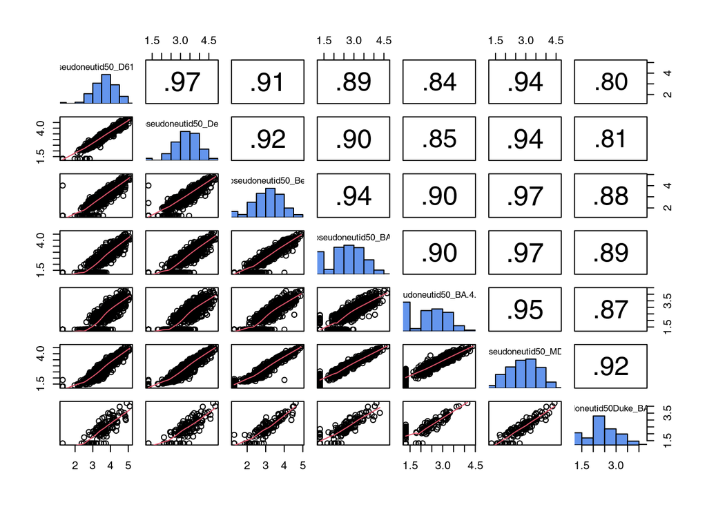

```r
dat=subset(dat_proc, ph1.D15 & TrtonedosemRNA==1)

mypairs(dat[,paste0("B",assays)])
```

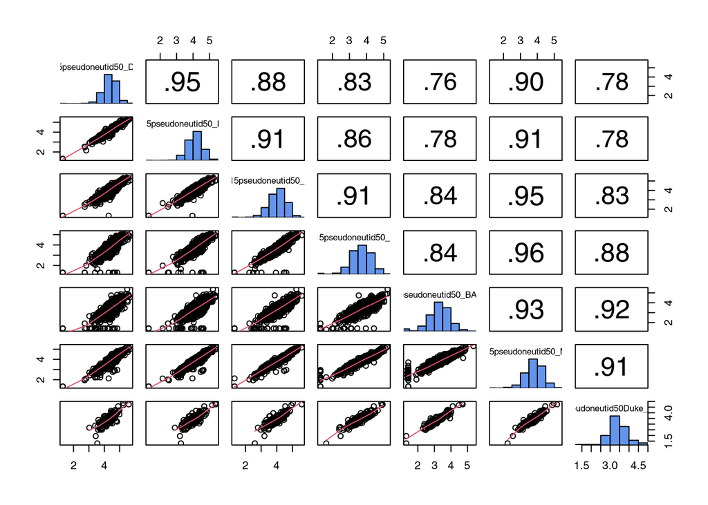

```r
mypairs(dat[,paste0("Day15",assays)])
```

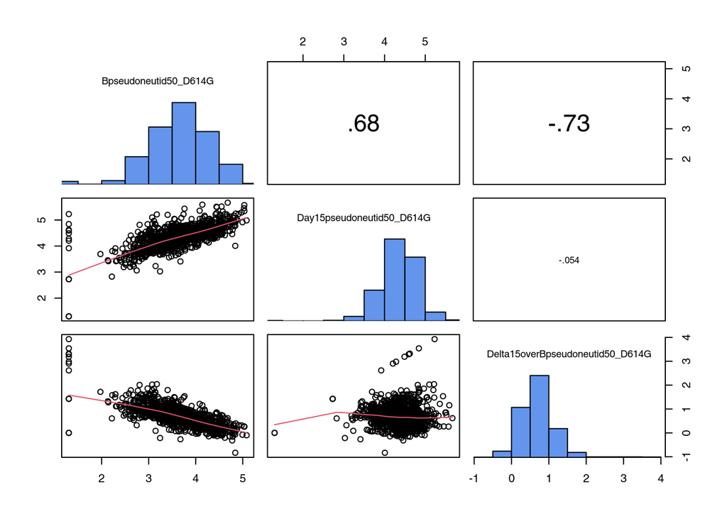

```r
mypairs(dat[,paste0(c("B","Day15", "Delta15overB"),assays[1])])
```

### marker missingness

```r
table(dat_proc$AsympInfectIndD15to29, dat_proc$ph1.D15)
```

```
##
##        0    1
##   0  110 1116
##   1    3   11
```

```r
table(dat_proc$arm, dat_proc$ph1.D15)
```

```
##
##        0   1
##   1    1  96
##   2    3 109
##   3   85   0
##   4    2  98
##   5    3  96
##   6    4  92
##   7    0  47
##   8    1  50
##   9    1  52
##   10   2  49
##   11   2  49
##   12   0  52
##   13   1  45
##   14   2  48
##   15   1  49
##   16   2  98
##   17   3  97
```

```r
table(dat_mapped$ph1.D15, dat_mapped$Immunemarkerset, dat_mapped$arm==3)
```

```
## , ,  = FALSE
##
##
##        0    1
##   0   49    0
##   1    0 1127
##
## , ,  = TRUE
##
##
##        0    1
##   0    1   85
##   1    0    0
```

```r
# across assays, all or none
summary(subset(dat_proc, ph1.D15 & is.na(Day29pseudoneutid50_D614G))["Day29"%.%assays[1:5]])
```

```
##  Day29pseudoneutid50_D614G Day29pseudoneutid50_Delta Day29pseudoneutid50_Beta
##  Min.   : NA               Min.   : NA               Min.   : NA
##  1st Qu.: NA               1st Qu.: NA               1st Qu.: NA
##  Median : NA               Median : NA               Median : NA
##  Mean   :NaN               Mean   :NaN               Mean   :NaN
##  3rd Qu.: NA               3rd Qu.: NA               3rd Qu.: NA
##  Max.   : NA               Max.   : NA               Max.   : NA
##  NA's   :15                NA's   :15                NA's   :15
##  Day29pseudoneutid50_BA.1 Day29pseudoneutid50_BA.4.BA.5
##  Min.   : NA              Min.   : NA
##  1st Qu.: NA              1st Qu.: NA
##  Median : NA              Median : NA
##  Mean   :NaN              Mean   :NaN
##  3rd Qu.: NA              3rd Qu.: NA
##  Max.   : NA              Max.   : NA
##  NA's   :15               NA's   :15
```

```r
summary(subset(dat_proc, ph1.D15 & is.na(Day91pseudoneutid50_D614G))["Day91"%.%assays[1:5]])
```

```
##  Day91pseudoneutid50_D614G Day91pseudoneutid50_Delta Day91pseudoneutid50_Beta
##  Min.   : NA               Min.   : NA               Min.   : NA
##  1st Qu.: NA               1st Qu.: NA               1st Qu.: NA
##  Median : NA               Median : NA               Median : NA
##  Mean   :NaN               Mean   :NaN               Mean   :NaN
##  3rd Qu.: NA               3rd Qu.: NA               3rd Qu.: NA
##  Max.   : NA               Max.   : NA               Max.   : NA
##  NA's   :27                NA's   :27                NA's   :27
##  Day91pseudoneutid50_BA.1 Day91pseudoneutid50_BA.4.BA.5
##  Min.   : NA              Min.   : NA
##  1st Qu.: NA              1st Qu.: NA
##  Median : NA              Median : NA
##  Mean   :NaN              Mean   :NaN
##  3rd Qu.: NA              3rd Qu.: NA
##  Max.   : NA              Max.   : NA
##  NA's   :27               NA's   :27
```

```r
summary(subset(dat_proc, ph1.D15 & is.na(Day181pseudoneutid50_D614G))["Day181"%.%assays[1:5]])
```

```
##  Day181pseudoneutid50_D614G Day181pseudoneutid50_Delta
##  Min.   : NA                Min.   : NA
##  1st Qu.: NA                1st Qu.: NA
##  Median : NA                Median : NA
##  Mean   :NaN                Mean   :NaN
##  3rd Qu.: NA                3rd Qu.: NA
##  Max.   : NA                Max.   : NA
##  NA's   :59                 NA's   :59
##  Day181pseudoneutid50_Beta Day181pseudoneutid50_BA.1
##  Min.   : NA               Min.   : NA
##  1st Qu.: NA               1st Qu.: NA
##  Median : NA               Median : NA
##  Mean   :NaN               Mean   :NaN
##  3rd Qu.: NA               3rd Qu.: NA
##  Max.   : NA               Max.   : NA
##  NA's   :59                NA's   :59
##  Day181pseudoneutid50_BA.4.BA.5
##  Min.   : NA
##  1st Qu.: NA
##  Median : NA
##  Mean   :NaN
##  3rd Qu.: NA
##  Max.   : NA
##  NA's   :59
```

```r
dat_proc$kp = dat_proc$ph1.D15==1 & dat_proc$COVIDIndD22toend!=1 & dat_proc$AsympInfectIndD15to271!=1
dat_proc$kp = dat_proc$ph1.D15==1
for (i in 1:1) {
  with(dat_proc[dat_proc$kp,], print(table(!is.na(get("Day29"%.%assays[i])), !is.na(get("Day15"%.%assays[i])))))
  with(dat_proc[dat_proc$kp,], print(table(!is.na(get("Day91"%.%assays[i])), !is.na(get("Day15"%.%assays[i])))))
  with(dat_proc[dat_proc$kp,], print(table(!is.na(get("Day181"%.%assays[i])), !is.na(get("Day15"%.%assays[i])))))
}
```

```
##
##         TRUE
##   FALSE   15
##   TRUE  1112
##
##         TRUE
##   FALSE   27
##   TRUE  1100
##
##         TRUE
##   FALSE   59
##   TRUE  1068
```

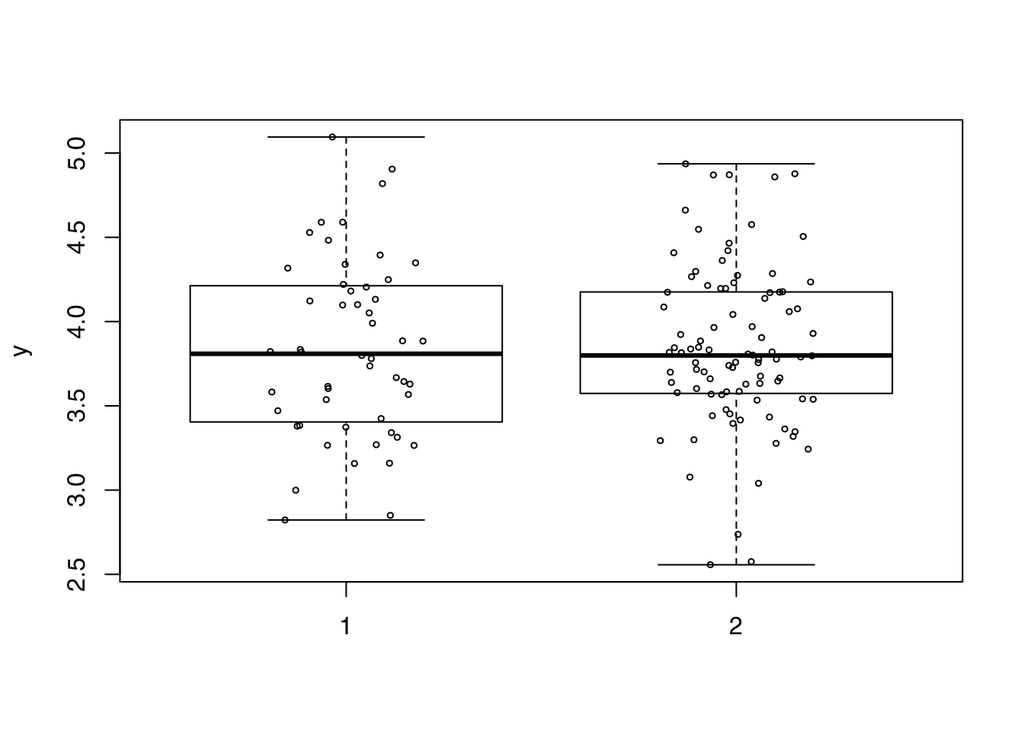

```r
myboxplot(
list(dat_proc$Day15pseudoneutid50_MDW[dat_proc$treatment_actual=="Omicron + Wildtype/Prototype (Pfizer 1)"],
     dat_proc$Day15pseudoneutid50_MDW[dat_proc$treatment_actual=="1 Dose Omicron + Prototype (Moderna)"])
)
```

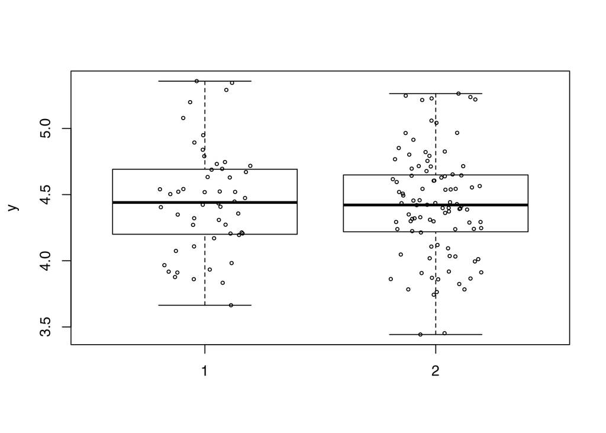

```r
myboxplot(
  list(dat_proc$Day15pseudoneutid50_D614G[dat_proc$treatment_actual=="Omicron + Wildtype/Prototype (Pfizer 1)"],
       dat_proc$Day15pseudoneutid50_D614G[dat_proc$treatment_actual=="1 Dose Omicron + Prototype (Moderna)"])
)
```

```r
# my.interaction.plot(subset(dat_proc, ph1==1,
#                            c(Bpseudoneutid50_BA.1, Day15pseudoneutid50_BA.1)),
#                     x.ori = 0, xaxislabels = c("B", "D15"), cex.axis = 1, add = T, xlab = "", ylab = "", pcol = NULL, lcol = NULL)
#
# my.interaction.plot(subset(dat_proc, ph1==1,
#                            c(Day15pseudoneutid50_BA.1, Day29pseudoneutid50_BA.1)),
#                     x.ori = 1, xaxislabels = c("D15", "D29"), cex.axis = 1, add = T, xlab = "", ylab = "", pcol = NULL, lcol = NULL)
#
# my.interaction.plot(subset(dat_proc, ph1==1,
#                            c(Day29pseudoneutid50_BA.1, Day91pseudoneutid50_BA.1)),
#                     x.ori = 2, xaxislabels = c("D29", "D91"), cex.axis = 1, add = T, xlab = "", ylab = "", pcol = NULL, lcol = NULL)
#
# my.interaction.plot(subset(dat_proc, ph1==1,
#                            c(Day91pseudoneutid50_BA.1, Day181pseudoneutid50_BA.1)),
#                     x.ori = 3, xaxislabels = c("D91", "D181"), cex.axis = 1, add = T, xlab = "", ylab = "", pcol = NULL, lcol = NULL)
#
```

### marker level over time

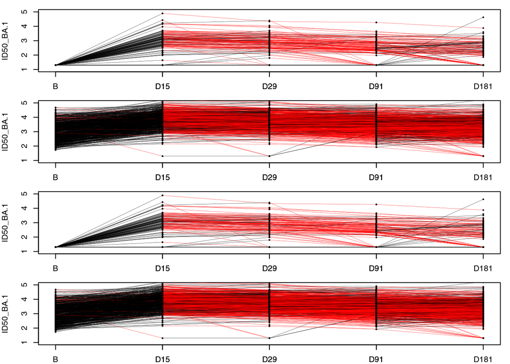

```r
par(mfrow=c(4,1), mar=c(2,4,1,1))

dat_proc$ph1 = dat_proc$ph1.D15==1 & dat_proc$COVIDIndD22toend!=1 & dat_proc$AsympInfectIndD15to181!=1 & dat_proc$AsympInfectIndD182to271!=1

plot(0,0,type='n', xlim=c(1,5), ylim=c(1,5), xaxt="n", xlab="", ylab="ID50_BA.1")

my.interaction.plot(subset(dat_proc, ph1==1 & Bpseudoneutid50_BA.1<1.5,
                           c(Bpseudoneutid50_BA.1, Day15pseudoneutid50_BA.1)),
                    x.ori = 0, xaxislabels = c("B", "D15"), cex.axis = 1, add = T, xlab = "", ylab = "", pcol = NULL, lcol = NULL)

my.interaction.plot(subset(dat_proc, ph1==1 & Bpseudoneutid50_BA.1<1.5,
                           c(Day15pseudoneutid50_BA.1, Day29pseudoneutid50_BA.1)),
                    x.ori = 1, xaxislabels = c("D15", "D29"), cex.axis = 1, add = T, xlab = "", ylab = "", pcol = NULL, lcol = NULL)

my.interaction.plot(subset(dat_proc, ph1==1 & Bpseudoneutid50_BA.1<1.5,
                           c(Day29pseudoneutid50_BA.1, Day91pseudoneutid50_BA.1)),
                    x.ori = 2, xaxislabels = c("D29", "D91"), cex.axis = 1, add = T, xlab = "", ylab = "", pcol = NULL, lcol = NULL)

my.interaction.plot(subset(dat_proc, ph1==1 & Bpseudoneutid50_BA.1<1.5,
                           c(Day91pseudoneutid50_BA.1, Day181pseudoneutid50_BA.1)),
                    x.ori = 3, xaxislabels = c("D91", "D181"), cex.axis = 1, add = T, xlab = "", ylab = "", pcol = NULL, lcol = NULL)


plot(0,0,type='n', xlim=c(1,5), ylim=c(1,5), xaxt="n", xlab="", ylab="ID50_BA.1")

my.interaction.plot(subset(dat_proc, ph1==1 & Bpseudoneutid50_BA.1>1.5,
                           c(Bpseudoneutid50_BA.1, Day15pseudoneutid50_BA.1)),
                    x.ori = 0, xaxislabels = c("B", "D15"), cex.axis = 1, add = T, xlab = "", ylab = "", pcol = NULL, lcol = NULL)

my.interaction.plot(subset(dat_proc, ph1==1 & Bpseudoneutid50_BA.1>1.5,
                           c(Day15pseudoneutid50_BA.1, Day29pseudoneutid50_BA.1)),
                    x.ori = 1, xaxislabels = c("D15", "D29"), cex.axis = 1, add = T, xlab = "", ylab = "", pcol = NULL, lcol = NULL)

my.interaction.plot(subset(dat_proc, ph1==1 & Bpseudoneutid50_BA.1>1.5,
                           c(Day29pseudoneutid50_BA.1, Day91pseudoneutid50_BA.1)),
                    x.ori = 2, xaxislabels = c("D29", "D91"), cex.axis = 1, add = T, xlab = "", ylab = "", pcol = NULL, lcol = NULL)

my.interaction.plot(subset(dat_proc, ph1==1 & Bpseudoneutid50_BA.1>1.5,
                           c(Day91pseudoneutid50_BA.1, Day181pseudoneutid50_BA.1)),
                    x.ori = 3, xaxislabels = c("D91", "D181"), cex.axis = 1, add = T, xlab = "", ylab = "", pcol = NULL, lcol = NULL)



dat_proc$ph1 = dat_proc$ph1.D92 & dat_proc$ph1.D15==1 & dat_proc$COVIDIndD22toend!=1 & dat_proc$AsympInfectIndD15to181!=1 & dat_proc$AsympInfectIndD182to271!=1

plot(0,0,type='n', xlim=c(1,5), ylim=c(1,5), xaxt="n", xlab="", ylab="ID50_BA.1")

my.interaction.plot(subset(dat_proc, ph1==1 & Bpseudoneutid50_BA.1<1.5,
                           c(Bpseudoneutid50_BA.1, Day15pseudoneutid50_BA.1)),
                    x.ori = 0, xaxislabels = c("B", "D15"), cex.axis = 1, add = T, xlab = "", ylab = "", pcol = NULL, lcol = NULL)

my.interaction.plot(subset(dat_proc, ph1==1 & Bpseudoneutid50_BA.1<1.5,
                           c(Day15pseudoneutid50_BA.1, Day29pseudoneutid50_BA.1)),
                    x.ori = 1, xaxislabels = c("D15", "D29"), cex.axis = 1, add = T, xlab = "", ylab = "", pcol = NULL, lcol = NULL)

my.interaction.plot(subset(dat_proc, ph1==1 & Bpseudoneutid50_BA.1<1.5,
                           c(Day29pseudoneutid50_BA.1, Day91pseudoneutid50_BA.1)),
                    x.ori = 2, xaxislabels = c("D29", "D91"), cex.axis = 1, add = T, xlab = "", ylab = "", pcol = NULL, lcol = NULL)

my.interaction.plot(subset(dat_proc, ph1==1 & Bpseudoneutid50_BA.1<1.5,
                           c(Day91pseudoneutid50_BA.1, Day181pseudoneutid50_BA.1)),
                    x.ori = 3, xaxislabels = c("D91", "D181"), cex.axis = 1, add = T, xlab = "", ylab = "", pcol = NULL, lcol = NULL)


plot(0,0,type='n', xlim=c(1,5), ylim=c(1,5), xaxt="n", xlab="", ylab="ID50_BA.1")

my.interaction.plot(subset(dat_proc, ph1==1 & Bpseudoneutid50_BA.1>1.5,
                           c(Bpseudoneutid50_BA.1, Day15pseudoneutid50_BA.1)),
                    x.ori = 0, xaxislabels = c("B", "D15"), cex.axis = 1, add = T, xlab = "", ylab = "", pcol = NULL, lcol = NULL)

my.interaction.plot(subset(dat_proc, ph1==1 & Bpseudoneutid50_BA.1>1.5,
                           c(Day15pseudoneutid50_BA.1, Day29pseudoneutid50_BA.1)),
                    x.ori = 1, xaxislabels = c("D15", "D29"), cex.axis = 1, add = T, xlab = "", ylab = "", pcol = NULL, lcol = NULL)

my.interaction.plot(subset(dat_proc, ph1==1 & Bpseudoneutid50_BA.1>1.5,
                           c(Day29pseudoneutid50_BA.1, Day91pseudoneutid50_BA.1)),
                    x.ori = 2, xaxislabels = c("D29", "D91"), cex.axis = 1, add = T, xlab = "", ylab = "", pcol = NULL, lcol = NULL)

my.interaction.plot(subset(dat_proc, ph1==1 & Bpseudoneutid50_BA.1>1.5,
                           c(Day91pseudoneutid50_BA.1, Day181pseudoneutid50_BA.1)),
                    x.ori = 3, xaxislabels = c("D91", "D181"), cex.axis = 1, add = T, xlab = "", ylab = "", pcol = NULL, lcol = NULL)
```

```r
sum(dat_proc$ph1.D15==1)
```

```
## [1] 1127
```

```r
dat_proc$kp = dat_proc$ph1.D15==1 & dat_proc$COVIDIndD22toend!=1 & dat_proc$AsympInfectIndD15to271!=1 &
  !is.na(dat_proc$Day29pseudoneutid50_D614G) & !is.na(dat_proc$Day91pseudoneutid50_D614G) & !is.na(dat_proc$Day181pseudoneutid50_D614G)

nrow(subset(dat_proc, kp))
```

```
## [1] 733
```

```r
nrow(subset(dat_proc, kp & Bpseudoneutid50_BA.1>1.5))
```

```
## [1] 619
```

```r
nrow(subset(dat_proc, kp & Bpseudoneutid50_BA.1<1.5))
```

```
## [1] 114
```

### Misc

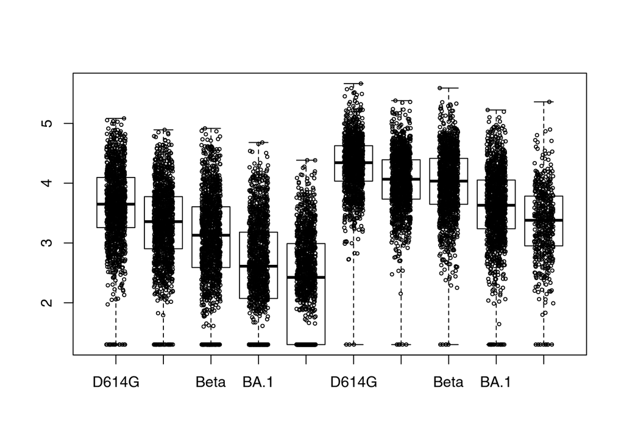

```r
myboxplot(dat_mapped[, c("B"%.%assays[1:5], "Day15"%.%assays[1:5])], names=sub("pseudoneutid50_", "", rep(assays[1:5],2)))
```

```r
summary(dat_mapped)
```

[output not shown]

[output cut: 393 more lines]

[output not shown]

```r
sort(names(dat_mapped))
```

```
##   [1] "Actual_visit_date_1.0"
##   [2] "Actual_visit_date_15.2"
##   [3] "Actual_visit_date_181.14"
##   [4] "Actual_visit_date_271.14"
##   [5] "Actual_visit_date_29.2"
##   [6] "Actual_visit_date_91.7"
##   [7] "Age"
##   [8] "Age65C"
##   [9] "arm"
##  [10] "Asian"
##  [11] "ASSAY"
##  [12] "ASSCOMP_SWAB1"
##  [13] "ASSCOMP_SWAB2"
##  [14] "ASSQC_SWAB1"
##  [15] "ASSQC_SWAB2"
```

[output cut: 174 more lines]

```r
table(dat_mapped$treatment_actual, dat_mapped$stage)
```

```
##
##                                                    1   2   3   4
##   1 Dose Beta + Omicron (Moderna)                113   0   0   0
##   1 Dose Delta + Omicron (Moderna)               101   0   0   0
##   1 Dose Omicron (Moderna)                        99   0   0   0
##   1 Dose Omicron + Prototype (Moderna)            99   0   0   0
##   1 Dose Prototype (Moderna)                      99   0   0   0
##   2 Dose Beta + Omicron (Moderna)                 86   0   0   0
##   Beta (Pfizer 1)                                  0  51   0   0
##   Beta (Sanofi)                                    0   0  51   0
##   Beta + Omicron (Pfizer 1)                        0  52   0   0
##   Beta + Prototype (Sanofi)                        0   0  52   0
##   Beta + Wildtype/Prototype (Pfizer 1)             0  52   0   0
##   Omicron (Pfizer 1)                               0  54   0   0
##   Omicron + Wildtype/Prototype (Pfizer 1)          0  53   0   0
##   Omicron BA.1 + Wildtype/Prototype (Pfizer 2)     0   0   0 101
##   Omicron BA.4/5 + Wildtype/Prototype (Pfizer 2)   0   0   0 100
##   Prototype (Sanofi)                               0   0  49   0
##   Wildtype/Prototype (Pfizer 1)                    0  50   0   0
```

```r
with(subset(dat, ph1.D15==1 & COVIDIndD22toD181), mytable(treatment_actual, COVIDlineageObserved))
```

```
##                                                 COVIDlineageObserved
## treatment_actual                                 FALSE TRUE
##   1 Dose Beta + Omicron (Moderna)                    9   28
##   1 Dose Delta + Omicron (Moderna)                   5   23
##   1 Dose Omicron (Moderna)                           7   18
##   1 Dose Omicron + Prototype (Moderna)               8   18
##   1 Dose Prototype (Moderna)                         7   20
##   Beta (Pfizer 1)                                    4    5
##   Beta + Omicron (Pfizer 1)                          3    4
##   Beta + Wildtype/Prototype (Pfizer 1)               2    7
##   Omicron (Pfizer 1)                                 5    3
##   Omicron + Wildtype/Prototype (Pfizer 1)            0    6
##   Omicron BA.1 + Wildtype/Prototype (Pfizer 2)       3    5
##   Omicron BA.4/5 + Wildtype/Prototype (Pfizer 2)     2    5
##   Wildtype/Prototype (Pfizer 1)                      4   12
```

```r
table(dat_mapped$Immunemarkerset, dat_mapped$Perprotocol, useNA='ifany')
```

```
##
##        0    1
##   0   26   24
##   1    0 1212
```

```r
table(dat_mapped$Immunemarkerset, dat_mapped$eligibility_deviation, useNA='ifany')
```

```
##
##             Y
##   0   47    3
##   1 1212    0
```